# Ford GoBike System Data

### DOCUMENT CONTENT

- Introduction
- Data Wrangling
  1. GATHER
  2. ASSESS
  3. CLEAN
- Data Analysis
  1. Univariate Exploration
  2. Bivariate Exploration
  3. Multivariate Exploration
- Summary

## INTRODUCTION

Bay Wheels is a regional public bicycle sharing system in California's San Francisco Bay Area. It is operated by Motivate in a partnership with the Metropolitan Transportation Commission and the Bay Area Air Quality Management District. Bay Wheels is the first regional and large-scale bicycle sharing system deployed in California and on the West Coast of the United States. It was established as Bay Area Bike Share in August 2013. As of January 2018, the Bay Wheels system had over 2,600 bicycles in 262 stations across San Francisco, East Bay and San Jose.

In June 2017 the system was officially re-launched as Ford GoBike in a partnership with Ford Motor Company. After Motivate's acquisition by Lyft, the system was renamed to Bay Wheels in June 2019. The system is expected to expand to 7,000 bicycles around 540 stations in San Francisco, Oakland, Berkeley, Emeryville, and San Jose.

## DATA WRANGLING

### 1. GATHER

```python
#import all packages
import pandas as pd
import numpy as np
import matplotlib.pyplot as plt
import seaborn as sb
%matplotlib inline
```

```python
df=pd.read_csv('201902-fordgobike-tripdata.csv')
df.head()
```

|  | duration_sec | start_time | end_time | start_station_id | start_station_name | start_station_latitude | start_station_longitude | end_station_id | end_station_name | end_station_latitude | end_station_longitude | bike_id | user_type | member_birth_year | member_gender | bike_share_for_all_trip |
| --- | --- | --- | --- | --- | --- | --- | --- | --- | --- | --- | --- | --- | --- | --- | --- | --- |
| 0 | 52185 | 2019-02-28 17:32:10.1450 | 2019-03-01 08:01:55.9750 | 21.0 | Montgomery St BART Station (Market St at 2nd St) | 37.789625 | -122.400811 | 13.0 | Commercial St at Montgomery St | 37.794231 | -122.402923 | 4902 | Customer | 1984.0 | Male | No |
| 1 | 42521 | 2019-02-28 18:53:21.7890 | 2019-03-01 06:42:03.0560 | 23.0 | The Embarcadero at Steuart St | 37.791464 | -122.391034 | 81.0 | Berry St at 4th St | 37.775880 | -122.393170 | 2535 | Customer | NaN | NaN | No |
| 2 | 61854 | 2019-02-28 12:13:13.2180 | 2019-03-01 05:24:08.1460 | 86.0 | Market St at Dolores St | 37.769305 | -122.426826 | 3.0 | Powell St BART Station (Market St at 4th St) | 37.786375 | -122.404904 | 5905 | Customer | 1972.0 | Male | No |
| 3 | 36490 | 2019-02-28 17:54:26.0100 | 2019-03-01 04:02:36.8420 | 375.0 | Grove St at Masonic Ave | 37.774836 | -122.446546 | 70.0 | Central Ave at Fell St | 37.773311 | -122.444293 | 6638 | Subscriber | 1989.0 | Other | No |
| 4 | 1585 | 2019-02-28 23:54:18.5490 | 2019-03-01 00:20:44.0740 | 7.0 | Frank H Ogawa Plaza | 37.804562 | -122.271738 | 222.0 | 10th Ave at E 15th St | 37.792714 | -122.248780 | 4898 | Subscriber | 1974.0 | Male | Yes |

### 2. ASSESS

```python
df.info()
```

```
<class 'pandas.core.frame.DataFrame'>
RangeIndex: 183412 entries, 0 to 183411
Data columns (total 16 columns):
duration_sec               183412 non-null int64
start_time                 183412 non-null object
end_time                   183412 non-null object
start_station_id           183215 non-null float64
start_station_name         183215 non-null object
start_station_latitude     183412 non-null float64
start_station_longitude    183412 non-null float64
end_station_id             183215 non-null float64
end_station_name           183215 non-null object
end_station_latitude       183412 non-null float64
end_station_longitude      183412 non-null float64
bike_id                    183412 non-null int64
user_type                  183412 non-null object
member_birth_year          175147 non-null float64
member_gender              175147 non-null object
bike_share_for_all_trip    183412 non-null object
dtypes: float64(7), int64(2), object(7)
memory usage: 22.4+ MB
```

DATA TYPE ASSESSMENT

```python
print(df.shape)
```

```
(183412, 16)
```

```python
df.describe()
```

|  | duration_sec | start_station_id | start_station_latitude | start_station_longitude | end_station_id | end_station_latitude | end_station_longitude | bike_id | member_birth_year |
| --- | --- | --- | --- | --- | --- | --- | --- | --- | --- |
| count | 183412.000000 | 183215.000000 | 183412.000000 | 183412.000000 | 183215.000000 | 183412.000000 | 183412.000000 | 183412.000000 | 175147.000000 |
| mean | 726.078435 | 138.590427 | 37.771223 | -122.352664 | 136.249123 | 37.771427 | -122.352250 | 4472.906375 | 1984.806437 |
| std | 1794.389780 | 111.778864 | 0.099581 | 0.117097 | 111.515131 | 0.099490 | 0.116673 | 1664.383394 | 10.116689 |
| min | 61.000000 | 3.000000 | 37.317298 | -122.453704 | 3.000000 | 37.317298 | -122.453704 | 11.000000 | 1878.000000 |
| 25% | 325.000000 | 47.000000 | 37.770083 | -122.412408 | 44.000000 | 37.770407 | -122.411726 | 3777.000000 | 1980.000000 |
| 50% | 514.000000 | 104.000000 | 37.780760 | -122.398285 | 100.000000 | 37.781010 | -122.398279 | 4958.000000 | 1987.000000 |
| 75% | 796.000000 | 239.000000 | 37.797280 | -122.286533 | 235.000000 | 37.797320 | -122.288045 | 5502.000000 | 1992.000000 |
| max | 85444.000000 | 398.000000 | 37.880222 | -121.874119 | 398.000000 | 37.880222 | -121.874119 | 6645.000000 | 2001.000000 |

- Minimum birth year is 1878. It is not possible.

```python
#start year is 2019. How old can the riders be?
df.start_time.min()
```

```
'2019-02-01 00:00:20.6360'
```

```python
#there are 203 rows where member birth date is less than 1940, older than 79
# I am not sure that these are reliable datas.
df[df['member_birth_year']<1940]
```

|  | duration_sec | start_time | end_time | start_station_id | start_station_name | start_station_latitude | start_station_longitude | end_station_id | end_station_name | end_station_latitude | end_station_longitude | bike_id | user_type | member_birth_year | member_gender | bike_share_for_all_trip |
| --- | --- | --- | --- | --- | --- | --- | --- | --- | --- | --- | --- | --- | --- | --- | --- | --- |
| 1285 | 148 | 2019-02-28 19:29:17.6270 | 2019-02-28 19:31:45.9670 | 158.0 | Shattuck Ave at Telegraph Ave | 37.833279 | -122.263490 | 173.0 | Shattuck Ave at 55th St | 37.840364 | -122.264488 | 5391 | Subscriber | 1900.0 | Male | Yes |
| 5197 | 217 | 2019-02-28 13:51:46.2380 | 2019-02-28 13:55:24.1270 | 70.0 | Central Ave at Fell St | 37.773311 | -122.444293 | 71.0 | Broderick St at Oak St | 37.773063 | -122.439078 | 5801 | Subscriber | 1931.0 | Male | No |
| 5266 | 384 | 2019-02-28 13:35:05.4280 | 2019-02-28 13:41:30.2230 | 84.0 | Duboce Park | 37.769201 | -122.433812 | 71.0 | Broderick St at Oak St | 37.773063 | -122.439078 | 6608 | Subscriber | 1931.0 | Male | No |
| 5447 | 147 | 2019-02-28 13:08:56.9350 | 2019-02-28 13:11:24.0620 | 84.0 | Duboce Park | 37.769201 | -122.433812 | 72.0 | Page St at Scott St | 37.772406 | -122.435650 | 5018 | Subscriber | 1931.0 | Male | No |
| 10827 | 1315 | 2019-02-27 19:21:34.4360 | 2019-02-27 19:43:30.0080 | 343.0 | Bryant St at 2nd St | 37.783172 | -122.393572 | 375.0 | Grove St at Masonic Ave | 37.774836 | -122.446546 | 6249 | Subscriber | 1900.0 | Male | No |
| 16087 | 1131 | 2019-02-27 08:37:36.8640 | 2019-02-27 08:56:28.0220 | 375.0 | Grove St at Masonic Ave | 37.774836 | -122.446546 | 36.0 | Folsom St at 3rd St | 37.783830 | -122.398870 | 4968 | Subscriber | 1900.0 | Male | No |
| 17981 | 366 | 2019-02-26 19:53:38.5280 | 2019-02-26 19:59:44.9680 | 50.0 | 2nd St at Townsend St | 37.780526 | -122.390288 | 21.0 | Montgomery St BART Station (Market St at 2nd St) | 37.789625 | -122.400811 | 5226 | Subscriber | 1920.0 | Male | No |
| 18885 | 432 | 2019-02-26 17:48:59.0160 | 2019-02-26 17:56:11.3700 | 21.0 | Montgomery St BART Station (Market St at 2nd St) | 37.789625 | -122.400811 | 50.0 | 2nd St at Townsend St | 37.780526 | -122.390288 | 5319 | Subscriber | 1920.0 | Male | No |
| 19375 | 641 | 2019-02-26 17:03:19.8550 | 2019-02-26 17:14:01.6190 | 9.0 | Broadway at Battery St | 37.798572 | -122.400869 | 30.0 | San Francisco Caltrain (Townsend St at 4th St) | 37.776598 | -122.395282 | 6164 | Customer | 1900.0 | Male | No |
| 20743 | 380 | 2019-02-26 10:57:07.7670 | 2019-02-26 11:03:28.1960 | 26.0 | 1st St at Folsom St | 37.787290 | -122.394380 | 61.0 | Howard St at 8th St | 37.776513 | -122.411306 | 5387 | Subscriber | 1933.0 | Female | Yes |
| 21424 | 1424 | 2019-02-26 08:58:02.9040 | 2019-02-26 09:21:47.7490 | 375.0 | Grove St at Masonic Ave | 37.774836 | -122.446546 | 343.0 | Bryant St at 2nd St | 37.783172 | -122.393572 | 5344 | Subscriber | 1900.0 | Male | No |
| 21506 | 701 | 2019-02-26 09:06:11.2390 | 2019-02-26 09:17:52.4420 | 67.0 | San Francisco Caltrain Station 2 (Townsend St... | 37.776639 | -122.395526 | 9.0 | Broadway at Battery St | 37.798572 | -122.400869 | 5337 | Customer | 1900.0 | Male | No |
| 24042 | 194 | 2019-02-25 18:58:10.6440 | 2019-02-25 19:01:25.3080 | 158.0 | Shattuck Ave at Telegraph Ave | 37.833279 | -122.263490 | 173.0 | Shattuck Ave at 55th St | 37.840364 | -122.264488 | 6363 | Subscriber | 1900.0 | Male | Yes |
| 26133 | 410 | 2019-02-25 13:38:12.0670 | 2019-02-25 13:45:02.2070 | 173.0 | Shattuck Ave at 55th St | 37.840364 | -122.264488 | 176.0 | MacArthur BART Station | 37.828410 | -122.266315 | 3311 | Subscriber | 1900.0 | Male | Yes |
| 26344 | 534 | 2019-02-25 12:43:50.2250 | 2019-02-25 12:52:45.1280 | 26.0 | 1st St at Folsom St | 37.787290 | -122.394380 | 61.0 | Howard St at 8th St | 37.776513 | -122.411306 | 5948 | Subscriber | 1933.0 | Female | Yes |
| 26488 | 334 | 2019-02-25 12:13:25.3300 | 2019-02-25 12:18:59.4340 | 71.0 | Broderick St at Oak St | 37.773063 | -122.439078 | 84.0 | Duboce Park | 37.769201 | -122.433812 | 3361 | Subscriber | 1931.0 | Male | No |
| 26535 | 119 | 2019-02-25 12:08:38.3110 | 2019-02-25 12:10:37.6600 | 71.0 | Broderick St at Oak St | 37.773063 | -122.439078 | 53.0 | Grove St at Divisadero | 37.775946 | -122.437777 | 6475 | Subscriber | 1931.0 | Male | No |
| 26568 | 135 | 2019-02-25 12:02:18.3600 | 2019-02-25 12:04:34.2720 | 71.0 | Broderick St at Oak St | 37.773063 | -122.439078 | 53.0 | Grove St at Divisadero | 37.775946 | -122.437777 | 6257 | Subscriber | 1931.0 | Male | No |
| 26604 | 294 | 2019-02-25 11:52:12.5370 | 2019-02-25 11:57:06.9850 | 85.0 | Church St at Duboce Ave | 37.770083 | -122.429156 | 53.0 | Grove St at Divisadero | 37.775946 | -122.437777 | 5814 | Subscriber | 1931.0 | Male | No |
| 26641 | 78 | 2019-02-25 11:50:14.7770 | 2019-02-25 11:51:33.5550 | 85.0 | Church St at Duboce Ave | 37.770083 | -122.429156 | 85.0 | Church St at Duboce Ave | 37.770083 | -122.429156 | 4361 | Subscriber | 1931.0 | Male | No |
| 26685 | 110 | 2019-02-25 11:40:27.3480 | 2019-02-25 11:42:17.7820 | 85.0 | Church St at Duboce Ave | 37.770083 | -122.429156 | 73.0 | Pierce St at Haight St | 37.771793 | -122.433708 | 6208 | Subscriber | 1931.0 | Male | No |
| 26718 | 138 | 2019-02-25 11:33:27.1720 | 2019-02-25 11:35:45.1760 | 71.0 | Broderick St at Oak St | 37.773063 | -122.439078 | 73.0 | Pierce St at Haight St | 37.771793 | -122.433708 | 6110 | Subscriber | 1931.0 | Male | No |
| 26757 | 81 | 2019-02-25 11:25:52.7530 | 2019-02-25 11:27:14.7060 | 375.0 | Grove St at Masonic Ave | 37.774836 | -122.446546 | 70.0 | Central Ave at Fell St | 37.773311 | -122.444293 | 579 | Subscriber | 1931.0 | Male | No |
| 26775 | 130 | 2019-02-25 11:21:03.4690 | 2019-02-25 11:23:13.5690 | 71.0 | Broderick St at Oak St | 37.773063 | -122.439078 | 70.0 | Central Ave at Fell St | 37.773311 | -122.444293 | 5354 | Subscriber | 1931.0 | Male | No |
| 26807 | 116 | 2019-02-25 11:14:28.4370 | 2019-02-25 11:16:25.2620 | 375.0 | Grove St at Masonic Ave | 37.774836 | -122.446546 | 70.0 | Central Ave at Fell St | 37.773311 | -122.444293 | 74 | Subscriber | 1931.0 | Male | No |
| 26828 | 139 | 2019-02-25 11:08:41.6020 | 2019-02-25 11:11:01.5590 | 71.0 | Broderick St at Oak St | 37.773063 | -122.439078 | 70.0 | Central Ave at Fell St | 37.773311 | -122.444293 | 1428 | Subscriber | 1931.0 | Male | No |
| 26906 | 82 | 2019-02-25 10:54:23.3210 | 2019-02-25 10:55:45.9020 | 85.0 | Church St at Duboce Ave | 37.770083 | -122.429156 | 86.0 | Market St at Dolores St | 37.769305 | -122.426826 | 1916 | Subscriber | 1931.0 | Male | No |
| 26917 | 67 | 2019-02-25 10:51:02.3820 | 2019-02-25 10:52:09.3940 | 85.0 | Church St at Duboce Ave | 37.770083 | -122.429156 | 86.0 | Market St at Dolores St | 37.769305 | -122.426826 | 2664 | Subscriber | 1931.0 | Male | No |
| 26935 | 221 | 2019-02-25 10:45:01.9730 | 2019-02-25 10:48:43.6070 | 76.0 | McCoppin St at Valencia St | 37.771662 | -122.422423 | 86.0 | Market St at Dolores St | 37.769305 | -122.426826 | 5423 | Subscriber | 1931.0 | Male | No |
| 26981 | 123 | 2019-02-25 10:38:50.6500 | 2019-02-25 10:40:54.6040 | 95.0 | Sanchez St at 15th St | 37.766219 | -122.431060 | 86.0 | Market St at Dolores St | 37.769305 | -122.426826 | 6582 | Subscriber | 1931.0 | Male | No |
| ... | ... | ... | ... | ... | ... | ... | ... | ... | ... | ... | ... | ... | ... | ... | ... | ... |
| 140748 | 481 | 2019-02-07 18:41:11.6500 | 2019-02-07 18:49:13.2540 | 25.0 | Howard St at 2nd St | 37.787522 | -122.397405 | 30.0 | San Francisco Caltrain (Townsend St at 4th St) | 37.776598 | -122.395282 | 5476 | Subscriber | 1902.0 | Female | No |
| 140869 | 1866 | 2019-02-07 18:10:14.4850 | 2019-02-07 18:41:20.9500 | 67.0 | San Francisco Caltrain Station 2 (Townsend St... | 37.776639 | -122.395526 | 76.0 | McCoppin St at Valencia St | 37.771662 | -122.422423 | 5539 | Customer | 1939.0 | Male | No |
| 143632 | 557 | 2019-02-07 14:47:05.5010 | 2019-02-07 14:56:23.3020 | 179.0 | Telegraph Ave at 27th St | 37.816073 | -122.267886 | 211.0 | Broadway at 40th St | 37.827757 | -122.256716 | 4549 | Subscriber | 1939.0 | Female | Yes |
| 144039 | 378 | 2019-02-07 13:24:05.8330 | 2019-02-07 13:30:23.9470 | 26.0 | 1st St at Folsom St | 37.787290 | -122.394380 | 349.0 | Howard St at Mary St | 37.781010 | -122.405666 | 5485 | Subscriber | 1933.0 | Female | Yes |
| 145215 | 509 | 2019-02-07 09:59:33.8220 | 2019-02-07 10:08:03.4800 | 349.0 | Howard St at Mary St | 37.781010 | -122.405666 | 27.0 | Beale St at Harrison St | 37.788059 | -122.391865 | 4811 | Subscriber | 1933.0 | Female | Yes |
| 145510 | 508 | 2019-02-07 09:34:11.5420 | 2019-02-07 09:42:40.4000 | 30.0 | San Francisco Caltrain (Townsend St at 4th St) | 37.776598 | -122.395282 | 26.0 | 1st St at Folsom St | 37.787290 | -122.394380 | 5541 | Subscriber | 1902.0 | Female | No |
| 147519 | 460 | 2019-02-07 07:44:28.2170 | 2019-02-07 07:52:08.3900 | 284.0 | Yerba Buena Center for the Arts (Howard St at ... | 37.784872 | -122.400876 | 30.0 | San Francisco Caltrain (Townsend St at 4th St) | 37.776598 | -122.395282 | 3646 | Subscriber | 1901.0 | Male | No |
| 149706 | 370 | 2019-02-06 18:58:13.9340 | 2019-02-06 19:04:24.9120 | 118.0 | Eureka Valley Recreation Center | 37.759177 | -122.436943 | 84.0 | Duboce Park | 37.769201 | -122.433812 | 5334 | Subscriber | 1931.0 | Male | No |
| 150108 | 727 | 2019-02-06 18:24:40.3100 | 2019-02-06 18:36:48.1830 | 81.0 | Berry St at 4th St | 37.775880 | -122.393170 | 284.0 | Yerba Buena Center for the Arts (Howard St at ... | 37.784872 | -122.400876 | 5356 | Subscriber | 1910.0 | Other | No |
| 151936 | 622 | 2019-02-06 16:42:11.9280 | 2019-02-06 16:52:34.2300 | 25.0 | Howard St at 2nd St | 37.787522 | -122.397405 | 30.0 | San Francisco Caltrain (Townsend St at 4th St) | 37.776598 | -122.395282 | 560 | Subscriber | 1902.0 | Female | No |
| 153357 | 892 | 2019-02-06 12:44:32.6590 | 2019-02-06 12:59:24.8640 | 88.0 | 11th St at Bryant St | 37.770030 | -122.411726 | 131.0 | 22nd St at Dolores St | 37.755000 | -122.425728 | 4400 | Subscriber | 1938.0 | Male | No |
| 153746 | 331 | 2019-02-06 11:48:52.0910 | 2019-02-06 11:54:23.6530 | 127.0 | Valencia St at 21st St | 37.756708 | -122.421025 | 110.0 | 17th & Folsom Street Park (17th St at Folsom St) | 37.763708 | -122.415204 | 5112 | Subscriber | 1938.0 | Male | No |
| 157035 | 335 | 2019-02-06 06:36:44.4810 | 2019-02-06 06:42:20.3080 | 84.0 | Duboce Park | 37.769201 | -122.433812 | 118.0 | Eureka Valley Recreation Center | 37.759177 | -122.436943 | 3303 | Subscriber | 1931.0 | Male | No |
| 159405 | 584 | 2019-02-05 17:59:16.2440 | 2019-02-05 18:09:00.9400 | 26.0 | 1st St at Folsom St | 37.787290 | -122.394380 | 5.0 | Powell St BART Station (Market St at 5th St) | 37.783899 | -122.408445 | 5098 | Subscriber | 1933.0 | Female | Yes |
| 161505 | 355 | 2019-02-05 14:43:59.2270 | 2019-02-05 14:49:54.2670 | 25.0 | Howard St at 2nd St | 37.787522 | -122.397405 | 30.0 | San Francisco Caltrain (Townsend St at 4th St) | 37.776598 | -122.395282 | 4928 | Subscriber | 1902.0 | Female | No |
| 162051 | 176 | 2019-02-05 13:00:00.6040 | 2019-02-05 13:02:57.5490 | 173.0 | Shattuck Ave at 55th St | 37.840364 | -122.264488 | 174.0 | Shattuck Ave at 51st St | 37.836801 | -122.264004 | 2442 | Subscriber | 1900.0 | Male | Yes |
| 163112 | 1640 | 2019-02-05 09:18:18.3970 | 2019-02-05 09:45:39.0160 | 377.0 | Fell St at Stanyan St | 37.771917 | -122.453704 | 36.0 | Folsom St at 3rd St | 37.783830 | -122.398870 | 2715 | Subscriber | 1900.0 | Male | No |
| 165505 | 255 | 2019-02-05 06:52:54.1940 | 2019-02-05 06:57:10.0830 | 84.0 | Duboce Park | 37.769201 | -122.433812 | 118.0 | Eureka Valley Recreation Center | 37.759177 | -122.436943 | 5381 | Subscriber | 1931.0 | Male | No |
| 167178 | 526 | 2019-02-04 17:36:54.1550 | 2019-02-04 17:45:41.1400 | 25.0 | Howard St at 2nd St | 37.787522 | -122.397405 | 30.0 | San Francisco Caltrain (Townsend St at 4th St) | 37.776598 | -122.395282 | 184 | Subscriber | 1902.0 | Female | No |
| 171086 | 1086 | 2019-02-04 06:30:33.3830 | 2019-02-04 06:48:39.8690 | 375.0 | Grove St at Masonic Ave | 37.774836 | -122.446546 | 36.0 | Folsom St at 3rd St | 37.783830 | -122.398870 | 4435 | Subscriber | 1900.0 | Male | No |
| 171757 | 94 | 2019-02-03 19:12:06.6070 | 2019-02-03 19:13:40.6710 | 173.0 | Shattuck Ave at 55th St | 37.840364 | -122.264488 | 174.0 | Shattuck Ave at 51st St | 37.836801 | -122.264004 | 4539 | Subscriber | 1900.0 | Male | Yes |
| 171996 | 1368 | 2019-02-03 17:33:54.6070 | 2019-02-03 17:56:42.9490 | 37.0 | 2nd St at Folsom St | 37.785000 | -122.395936 | 375.0 | Grove St at Masonic Ave | 37.774836 | -122.446546 | 4988 | Subscriber | 1900.0 | Male | No |
| 173711 | 993 | 2019-02-03 09:45:30.4640 | 2019-02-03 10:02:04.1690 | 375.0 | Grove St at Masonic Ave | 37.774836 | -122.446546 | 36.0 | Folsom St at 3rd St | 37.783830 | -122.398870 | 5445 | Subscriber | 1900.0 | Male | No |
| 175394 | 1310 | 2019-02-02 14:17:10.2320 | 2019-02-02 14:39:00.4120 | 85.0 | Church St at Duboce Ave | 37.770083 | -122.429156 | 89.0 | Division St at Potrero Ave | 37.769218 | -122.407646 | 5125 | Customer | 1939.0 | Male | No |
| 177708 | 1527 | 2019-02-01 19:09:28.3870 | 2019-02-01 19:34:55.9630 | 343.0 | Bryant St at 2nd St | 37.783172 | -122.393572 | 375.0 | Grove St at Masonic Ave | 37.774836 | -122.446546 | 5286 | Subscriber | 1900.0 | Male | No |
| 177885 | 517 | 2019-02-01 18:38:40.4710 | 2019-02-01 18:47:18.3920 | 25.0 | Howard St at 2nd St | 37.787522 | -122.397405 | 30.0 | San Francisco Caltrain (Townsend St at 4th St) | 37.776598 | -122.395282 | 2175 | Subscriber | 1902.0 | Female | No |
| 177955 | 377 | 2019-02-01 18:23:33.4110 | 2019-02-01 18:29:50.7950 | 26.0 | 1st St at Folsom St | 37.787290 | -122.394380 | 321.0 | 5th St at Folsom | 37.780146 | -122.403071 | 5444 | Subscriber | 1933.0 | Female | Yes |
| 179280 | 355 | 2019-02-01 14:32:42.2470 | 2019-02-01 14:38:37.8960 | 134.0 | Valencia St at 24th St | 37.752428 | -122.420628 | 131.0 | 22nd St at Dolores St | 37.755000 | -122.425728 | 1815 | Subscriber | 1938.0 | Male | No |
| 182830 | 428 | 2019-02-01 07:45:05.9340 | 2019-02-01 07:52:14.9220 | 284.0 | Yerba Buena Center for the Arts (Howard St at ... | 37.784872 | -122.400876 | 67.0 | San Francisco Caltrain Station 2 (Townsend St... | 37.776639 | -122.395526 | 5031 | Subscriber | 1901.0 | Male | No |
| 183388 | 490 | 2019-02-01 00:39:53.1120 | 2019-02-01 00:48:03.3380 | 61.0 | Howard St at 8th St | 37.776513 | -122.411306 | 81.0 | Berry St at 4th St | 37.775880 | -122.393170 | 5411 | Subscriber | 1927.0 | Male | No |

203 rows × 16 columns

```python
df.isnull().sum()
```

```
duration_sec                  0
start_time                    0
end_time                      0
start_station_id            197
start_station_name          197
start_station_latitude        0
start_station_longitude       0
end_station_id              197
end_station_name            197
end_station_latitude          0
end_station_longitude         0
bike_id                       0
user_type                     0
member_birth_year          8265
member_gender              8265
bike_share_for_all_trip       0
dtype: int64
```

MISSING DATA ASSESSMENT

- 197 data missing for start_station_id,start_station name,end_station_id,end_station name
- 8265 data missing for member_birth_day and member_gender

```python
# Missing value rows are same for start&end station id and name.
df[(df['start_station_id'].isnull()) & (df['start_station_name'].isnull()) & (df['end_station_id'].isnull()) & (df['end_station_name'].isnull())]
```

|  | duration_sec | start_time | end_time | start_station_id | start_station_name | start_station_latitude | start_station_longitude | end_station_id | end_station_name | end_station_latitude | end_station_longitude | bike_id | user_type | member_birth_year | member_gender | bike_share_for_all_trip |
| --- | --- | --- | --- | --- | --- | --- | --- | --- | --- | --- | --- | --- | --- | --- | --- | --- |
| 475 | 1709 | 2019-02-28 20:55:53.9320 | 2019-02-28 21:24:23.7380 | NaN | NaN | 37.40 | -121.94 | NaN | NaN | 37.40 | -121.93 | 4211 | Customer | 1991.0 | Female | No |
| 1733 | 1272 | 2019-02-28 18:32:34.2730 | 2019-02-28 18:53:46.7270 | NaN | NaN | 37.40 | -121.94 | NaN | NaN | 37.41 | -121.96 | 4174 | Subscriber | 1980.0 | Male | No |
| 3625 | 142 | 2019-02-28 17:10:46.5290 | 2019-02-28 17:13:09.4310 | NaN | NaN | 37.41 | -121.95 | NaN | NaN | 37.41 | -121.96 | 4283 | Subscriber | 1988.0 | Male | No |
| 4070 | 585 | 2019-02-28 16:28:45.9340 | 2019-02-28 16:38:31.3320 | NaN | NaN | 37.39 | -121.93 | NaN | NaN | 37.40 | -121.92 | 4089 | Subscriber | 1984.0 | Male | Yes |
| 5654 | 509 | 2019-02-28 12:30:17.1310 | 2019-02-28 12:38:46.3290 | NaN | NaN | 37.40 | -121.92 | NaN | NaN | 37.39 | -121.93 | 4089 | Subscriber | 1984.0 | Male | Yes |
| 6214 | 1334 | 2019-02-28 10:32:47.9300 | 2019-02-28 10:55:02.0280 | NaN | NaN | 37.40 | -121.93 | NaN | NaN | 37.38 | -121.93 | 4150 | Customer | 1990.0 | Male | No |
| 8499 | 240 | 2019-02-28 08:23:07.0920 | 2019-02-28 08:27:07.2890 | NaN | NaN | 37.41 | -121.96 | NaN | NaN | 37.41 | -121.95 | 4283 | Subscriber | 1988.0 | Male | No |
| 8783 | 883 | 2019-02-28 07:58:07.3720 | 2019-02-28 08:12:51.2760 | NaN | NaN | 37.41 | -121.96 | NaN | NaN | 37.40 | -121.94 | 4211 | Subscriber | 1980.0 | Male | No |
| 10967 | 116 | 2019-02-27 19:25:57.0360 | 2019-02-27 19:27:54.0260 | NaN | NaN | 37.41 | -121.95 | NaN | NaN | 37.41 | -121.95 | 4283 | Subscriber | 1988.0 | Male | No |
| 11071 | 828 | 2019-02-27 19:03:14.6380 | 2019-02-27 19:17:03.4340 | NaN | NaN | 37.40 | -121.94 | NaN | NaN | 37.41 | -121.96 | 4091 | Subscriber | 1980.0 | Male | No |
| 13945 | 399 | 2019-02-27 14:06:51.7720 | 2019-02-27 14:13:31.6720 | NaN | NaN | 37.41 | -121.95 | NaN | NaN | 37.41 | -121.96 | 3975 | Subscriber | 1995.0 | Male | Yes |
| 14073 | 402 | 2019-02-27 13:37:01.8640 | 2019-02-27 13:43:44.3600 | NaN | NaN | 37.41 | -121.95 | NaN | NaN | 37.41 | -121.95 | 3975 | Subscriber | 1995.0 | Male | Yes |
| 14115 | 870 | 2019-02-27 13:17:28.6630 | 2019-02-27 13:31:59.1710 | NaN | NaN | 37.40 | -121.93 | NaN | NaN | 37.41 | -121.95 | 4168 | Customer | 1982.0 | Male | No |
| 14276 | 856 | 2019-02-27 12:42:38.9310 | 2019-02-27 12:56:55.0260 | NaN | NaN | 37.41 | -121.94 | NaN | NaN | 37.41 | -121.96 | 4211 | Subscriber | 1999.0 | Female | No |
| 15298 | 890 | 2019-02-27 09:33:32.5720 | 2019-02-27 09:48:23.0750 | NaN | NaN | 37.41 | -121.96 | NaN | NaN | 37.41 | -121.94 | 4211 | Subscriber | 1999.0 | Female | No |
| 15932 | 186 | 2019-02-27 09:01:57.4740 | 2019-02-27 09:05:03.9760 | NaN | NaN | 37.41 | -121.96 | NaN | NaN | 37.41 | -121.95 | 4283 | Subscriber | 1988.0 | Male | No |
| 16746 | 1005 | 2019-02-27 08:00:53.5280 | 2019-02-27 08:17:38.5340 | NaN | NaN | 37.41 | -121.96 | NaN | NaN | 37.40 | -121.94 | 4091 | Subscriber | 1980.0 | Male | No |
| 17749 | 316 | 2019-02-26 20:50:30.7760 | 2019-02-26 20:55:47.0760 | NaN | NaN | 37.41 | -121.96 | NaN | NaN | 37.41 | -121.95 | 4239 | Customer | 1992.0 | Male | No |
| 17908 | 393 | 2019-02-26 20:11:35.0800 | 2019-02-26 20:18:08.6700 | NaN | NaN | 37.40 | -121.94 | NaN | NaN | 37.40 | -121.93 | 4250 | Subscriber | 1990.0 | Male | No |
| 18573 | 142 | 2019-02-26 18:22:48.7720 | 2019-02-26 18:25:10.7740 | NaN | NaN | 37.41 | -121.95 | NaN | NaN | 37.41 | -121.95 | 4283 | Subscriber | 1988.0 | Male | No |
| 18639 | 954 | 2019-02-26 18:02:37.2290 | 2019-02-26 18:18:32.0650 | NaN | NaN | 37.40 | -121.94 | NaN | NaN | 37.41 | -121.96 | 4239 | Subscriber | 1980.0 | Male | No |
| 19033 | 913 | 2019-02-26 17:29:26.5680 | 2019-02-26 17:44:39.7700 | NaN | NaN | 37.40 | -121.93 | NaN | NaN | 37.40 | -121.93 | 4168 | Customer | 1987.0 | Female | No |
| 19932 | 327 | 2019-02-26 15:00:30.5340 | 2019-02-26 15:05:58.0320 | NaN | NaN | 37.41 | -121.95 | NaN | NaN | 37.41 | -121.95 | 4124 | Subscriber | 1999.0 | Male | No |
| 21233 | 170 | 2019-02-26 09:30:48.1350 | 2019-02-26 09:33:38.6190 | NaN | NaN | 37.41 | -121.96 | NaN | NaN | 37.41 | -121.95 | 4283 | Subscriber | 1988.0 | Male | No |
| 22306 | 1123 | 2019-02-26 08:05:08.6320 | 2019-02-26 08:23:52.0330 | NaN | NaN | 37.41 | -121.96 | NaN | NaN | 37.40 | -121.94 | 4239 | Subscriber | 1980.0 | Male | No |
| 22893 | 301 | 2019-02-26 02:10:14.2240 | 2019-02-26 02:15:15.7340 | NaN | NaN | 37.41 | -121.95 | NaN | NaN | 37.41 | -121.96 | 4239 | Customer | 1992.0 | Male | No |
| 23515 | 352 | 2019-02-25 20:13:00.9730 | 2019-02-25 20:18:53.0700 | NaN | NaN | 37.41 | -121.96 | NaN | NaN | 37.41 | -121.96 | 4239 | Customer | 1992.0 | Male | No |
| 24102 | 150 | 2019-02-25 18:53:35.2670 | 2019-02-25 18:56:05.3730 | NaN | NaN | 37.41 | -121.95 | NaN | NaN | 37.41 | -121.95 | 4283 | Subscriber | 1988.0 | Male | No |
| 24429 | 806 | 2019-02-25 18:11:33.0340 | 2019-02-25 18:24:59.5310 | NaN | NaN | 37.41 | -121.94 | NaN | NaN | 37.41 | -121.94 | 4189 | Subscriber | 1994.0 | Female | Yes |
| 24539 | 997 | 2019-02-25 17:57:40.5330 | 2019-02-25 18:14:18.3300 | NaN | NaN | 37.40 | -121.94 | NaN | NaN | 37.41 | -121.96 | 4239 | Subscriber | 1980.0 | Male | No |
| ... | ... | ... | ... | ... | ... | ... | ... | ... | ... | ... | ... | ... | ... | ... | ... | ... |
| 130572 | 1200 | 2019-02-09 16:36:30.3070 | 2019-02-09 16:56:31.2460 | NaN | NaN | 37.40 | -121.93 | NaN | NaN | 37.40 | -121.93 | 4245 | Customer | 1984.0 | Female | No |
| 130846 | 481 | 2019-02-09 15:09:44.3840 | 2019-02-09 15:17:45.7220 | NaN | NaN | 37.42 | -121.95 | NaN | NaN | 37.41 | -121.96 | 4141 | Subscriber | 1999.0 | Male | No |
| 130944 | 339 | 2019-02-09 14:40:39.5040 | 2019-02-09 14:46:18.8620 | NaN | NaN | 37.41 | -121.95 | NaN | NaN | 37.42 | -121.95 | 4141 | Subscriber | 1999.0 | Male | No |
| 131475 | 527 | 2019-02-09 12:24:39.8020 | 2019-02-09 12:33:26.9450 | NaN | NaN | 37.42 | -121.96 | NaN | NaN | 37.41 | -121.96 | 4239 | Subscriber | 1977.0 | Male | No |
| 131502 | 795 | 2019-02-09 12:10:29.1640 | 2019-02-09 12:23:44.7060 | NaN | NaN | 37.40 | -121.94 | NaN | NaN | 37.40 | -121.94 | 4174 | Customer | 1988.0 | Female | No |
| 131575 | 2233 | 2019-02-09 11:26:46.8750 | 2019-02-09 12:04:00.0710 | NaN | NaN | 37.41 | -121.95 | NaN | NaN | 37.42 | -121.96 | 4130 | Customer | 1991.0 | Male | No |
| 131645 | 303 | 2019-02-09 11:28:57.1210 | 2019-02-09 11:34:01.0220 | NaN | NaN | 37.42 | -121.95 | NaN | NaN | 37.42 | -121.96 | 4239 | Subscriber | 1977.0 | Male | No |
| 131750 | 276 | 2019-02-09 11:02:12.2670 | 2019-02-09 11:06:49.1040 | NaN | NaN | 37.41 | -121.95 | NaN | NaN | 37.42 | -121.95 | 4239 | Subscriber | 1977.0 | Male | No |
| 132593 | 439 | 2019-02-08 23:52:25.8470 | 2019-02-08 23:59:44.9270 | NaN | NaN | 37.42 | -121.95 | NaN | NaN | 37.41 | -121.94 | 4162 | Customer | 1981.0 | Male | No |
| 135455 | 6725 | 2019-02-08 11:06:42.2950 | 2019-02-08 12:58:48.2570 | NaN | NaN | 37.41 | -121.96 | NaN | NaN | 37.41 | -121.96 | 4092 | Subscriber | 1999.0 | Male | No |
| 136317 | 1927 | 2019-02-08 09:41:14.3240 | 2019-02-08 10:13:22.0890 | NaN | NaN | 37.41 | -121.94 | NaN | NaN | 37.41 | -121.98 | 4125 | Customer | 1989.0 | Male | No |
| 137030 | 838 | 2019-02-08 08:57:23.1240 | 2019-02-08 09:11:21.5430 | NaN | NaN | 37.41 | -121.94 | NaN | NaN | 37.40 | -121.92 | 4249 | Subscriber | 1976.0 | Male | No |
| 142719 | 2031 | 2019-02-07 16:23:38.5680 | 2019-02-07 16:57:29.7450 | NaN | NaN | 37.41 | -121.98 | NaN | NaN | 37.41 | -121.94 | 4125 | Customer | 1989.0 | Male | No |
| 142864 | 3064 | 2019-02-07 15:53:33.2350 | 2019-02-07 16:44:37.8200 | NaN | NaN | 37.41 | -121.95 | NaN | NaN | 37.43 | -121.92 | 4275 | Customer | 1986.0 | Male | No |
| 144928 | 349 | 2019-02-07 10:39:21.0240 | 2019-02-07 10:45:10.3850 | NaN | NaN | 37.42 | -121.94 | NaN | NaN | 37.41 | -121.95 | 4157 | Subscriber | 2000.0 | Female | Yes |
| 145154 | 1503 | 2019-02-07 09:49:31.9250 | 2019-02-07 10:14:35.8680 | NaN | NaN | 37.41 | -121.95 | NaN | NaN | 37.41 | -121.98 | 4125 | Customer | 1989.0 | Male | No |
| 152178 | 366 | 2019-02-06 16:20:37.1020 | 2019-02-06 16:26:43.1650 | NaN | NaN | 37.41 | -121.95 | NaN | NaN | 37.42 | -121.94 | 4157 | Subscriber | 2000.0 | Female | Yes |
| 152648 | 660 | 2019-02-06 15:07:33.9600 | 2019-02-06 15:18:34.5620 | NaN | NaN | 37.40 | -121.92 | NaN | NaN | 37.41 | -121.94 | 4249 | Subscriber | 1976.0 | Male | No |
| 153088 | 789 | 2019-02-06 13:32:34.6330 | 2019-02-06 13:45:44.3340 | NaN | NaN | 37.41 | -121.94 | NaN | NaN | 37.41 | -121.96 | 4092 | Subscriber | 1999.0 | Female | No |
| 154695 | 968 | 2019-02-06 09:19:56.8780 | 2019-02-06 09:36:05.2380 | NaN | NaN | 37.41 | -121.96 | NaN | NaN | 37.41 | -121.94 | 4092 | Subscriber | 1999.0 | Female | No |
| 155470 | 984 | 2019-02-06 08:39:02.6480 | 2019-02-06 08:55:26.6830 | NaN | NaN | 37.41 | -121.94 | NaN | NaN | 37.40 | -121.92 | 4249 | Subscriber | 1976.0 | Male | No |
| 161400 | 1159 | 2019-02-05 14:53:30.4310 | 2019-02-05 15:12:49.4460 | NaN | NaN | 37.40 | -121.94 | NaN | NaN | 37.40 | -121.94 | 4174 | Customer | 1986.0 | Male | No |
| 161844 | 823 | 2019-02-05 13:28:05.5940 | 2019-02-05 13:41:49.3090 | NaN | NaN | 37.41 | -121.94 | NaN | NaN | 37.41 | -121.96 | 4092 | Subscriber | 1999.0 | Male | No |
| 172481 | 3791 | 2019-02-03 14:53:55.9470 | 2019-02-03 15:57:07.0860 | NaN | NaN | 37.40 | -121.94 | NaN | NaN | 37.40 | -121.94 | 4174 | Subscriber | 1977.0 | Male | No |
| 174807 | 8209 | 2019-02-02 14:26:59.9650 | 2019-02-02 16:43:49.5180 | NaN | NaN | 37.40 | -121.93 | NaN | NaN | 37.41 | -121.94 | 4249 | Subscriber | 1993.0 | Male | Yes |
| 176154 | 1447 | 2019-02-02 12:03:04.5440 | 2019-02-02 12:27:12.2670 | NaN | NaN | 37.40 | -121.93 | NaN | NaN | 37.40 | -121.93 | 4249 | Customer | 1984.0 | Male | No |
| 179730 | 309 | 2019-02-01 12:59:45.9690 | 2019-02-01 13:04:55.4260 | NaN | NaN | 37.40 | -121.94 | NaN | NaN | 37.40 | -121.93 | 4249 | Customer | 1987.0 | Female | No |
| 179970 | 659 | 2019-02-01 12:17:37.6750 | 2019-02-01 12:28:37.0140 | NaN | NaN | 37.41 | -121.96 | NaN | NaN | 37.41 | -121.94 | 4092 | Subscriber | 1999.0 | Female | No |
| 180106 | 2013 | 2019-02-01 11:33:55.1470 | 2019-02-01 12:07:28.9400 | NaN | NaN | 37.40 | -121.94 | NaN | NaN | 37.40 | -121.94 | 4251 | Customer | 1990.0 | Female | No |
| 181201 | 312 | 2019-02-01 09:26:34.8030 | 2019-02-01 09:31:46.9210 | NaN | NaN | 37.40 | -121.93 | NaN | NaN | 37.40 | -121.93 | 4208 | Subscriber | 1987.0 | Male | No |

197 rows × 16 columns

```python
# Missing member birth date and gender at same row
df[(df['member_birth_year'].isnull()) & (df['member_gender'].isnull())]
```

|  | duration_sec | start_time | end_time | start_station_id | start_station_name | start_station_latitude | start_station_longitude | end_station_id | end_station_name | end_station_latitude | end_station_longitude | bike_id | user_type | member_birth_year | member_gender | bike_share_for_all_trip |
| --- | --- | --- | --- | --- | --- | --- | --- | --- | --- | --- | --- | --- | --- | --- | --- | --- |
| 1 | 42521 | 2019-02-28 18:53:21.7890 | 2019-03-01 06:42:03.0560 | 23.0 | The Embarcadero at Steuart St | 37.791464 | -122.391034 | 81.0 | Berry St at 4th St | 37.775880 | -122.393170 | 2535 | Customer | NaN | NaN | No |
| 13 | 915 | 2019-02-28 23:49:06.0620 | 2019-03-01 00:04:21.8670 | 252.0 | Channing Way at Shattuck Ave | 37.865847 | -122.267443 | 244.0 | Shattuck Ave at Hearst Ave | 37.873676 | -122.268487 | 5101 | Subscriber | NaN | NaN | No |
| 28 | 650 | 2019-02-28 23:43:27.5030 | 2019-02-28 23:54:18.4510 | 258.0 | University Ave at Oxford St | 37.872355 | -122.266447 | 263.0 | Channing Way at San Pablo Ave | 37.862827 | -122.290230 | 4784 | Customer | NaN | NaN | No |
| 53 | 3418 | 2019-02-28 22:41:16.3620 | 2019-02-28 23:38:14.3630 | 11.0 | Davis St at Jackson St | 37.797280 | -122.398436 | 11.0 | Davis St at Jackson St | 37.797280 | -122.398436 | 319 | Customer | NaN | NaN | No |
| 65 | 926 | 2019-02-28 23:17:05.8530 | 2019-02-28 23:32:32.6820 | 13.0 | Commercial St at Montgomery St | 37.794231 | -122.402923 | 81.0 | Berry St at 4th St | 37.775880 | -122.393170 | 2951 | Subscriber | NaN | NaN | No |
| 147 | 372 | 2019-02-28 22:46:19.1140 | 2019-02-28 22:52:31.4770 | 369.0 | Hyde St at Post St | 37.787349 | -122.416651 | 43.0 | San Francisco Public Library (Grove St at Hyde... | 37.778768 | -122.415929 | 2191 | Customer | NaN | NaN | No |
| 176 | 730 | 2019-02-28 22:28:50.5140 | 2019-02-28 22:41:00.8970 | 263.0 | Channing Way at San Pablo Ave | 37.862827 | -122.290230 | 258.0 | University Ave at Oxford St | 37.872355 | -122.266447 | 4784 | Customer | NaN | NaN | No |
| 220 | 1425 | 2019-02-28 22:05:25.5530 | 2019-02-28 22:29:11.1180 | 8.0 | The Embarcadero at Vallejo St | 37.799953 | -122.398525 | 109.0 | 17th St at Valencia St | 37.763316 | -122.421904 | 6525 | Subscriber | NaN | NaN | No |
| 266 | 1302 | 2019-02-28 21:53:13.2740 | 2019-02-28 22:14:56.1730 | 181.0 | Grand Ave at Webster St | 37.811377 | -122.265192 | 158.0 | Shattuck Ave at Telegraph Ave | 37.833279 | -122.263490 | 2471 | Customer | NaN | NaN | No |
| 292 | 1468 | 2019-02-28 21:43:04.3630 | 2019-02-28 22:07:32.6640 | 321.0 | 5th St at Folsom | 37.780146 | -122.403071 | 29.0 | O'Farrell St at Divisadero St | 37.782405 | -122.439446 | 6040 | Customer | NaN | NaN | No |
| 323 | 275 | 2019-02-28 21:52:54.9590 | 2019-02-28 21:57:30.5860 | 198.0 | Snow Park | 37.807813 | -122.264496 | 196.0 | Grand Ave at Perkins St | 37.808894 | -122.256460 | 2733 | Subscriber | NaN | NaN | No |
| 329 | 614 | 2019-02-28 21:45:47.5210 | 2019-02-28 21:56:02.0820 | 98.0 | Valencia St at 16th St | 37.765052 | -122.421866 | 139.0 | Garfield Square (25th St at Harrison St) | 37.751017 | -122.411901 | 6498 | Customer | NaN | NaN | No |
| 369 | 784 | 2019-02-28 21:34:04.0330 | 2019-02-28 21:47:08.2180 | 44.0 | Civic Center/UN Plaza BART Station (Market St ... | 37.781074 | -122.411738 | 26.0 | 1st St at Folsom St | 37.787290 | -122.394380 | 4930 | Subscriber | NaN | NaN | No |
| 371 | 320 | 2019-02-28 21:41:14.0510 | 2019-02-28 21:46:34.7440 | 252.0 | Channing Way at Shattuck Ave | 37.865847 | -122.267443 | 244.0 | Shattuck Ave at Hearst Ave | 37.873676 | -122.268487 | 4509 | Customer | NaN | NaN | No |
| 407 | 382 | 2019-02-28 21:32:00.4030 | 2019-02-28 21:38:22.9040 | 50.0 | 2nd St at Townsend St | 37.780526 | -122.390288 | 21.0 | Montgomery St BART Station (Market St at 2nd St) | 37.789625 | -122.400811 | 6577 | Subscriber | NaN | NaN | No |
| 422 | 462 | 2019-02-28 21:28:29.4510 | 2019-02-28 21:36:11.4770 | 285.0 | Webster St at O'Farrell St | 37.783521 | -122.431158 | 370.0 | Jones St at Post St | 37.787327 | -122.413278 | 5536 | Subscriber | NaN | NaN | No |
| 456 | 595 | 2019-02-28 21:18:14.9580 | 2019-02-28 21:28:10.3180 | 61.0 | Howard St at 8th St | 37.776513 | -122.411306 | 67.0 | San Francisco Caltrain Station 2 (Townsend St... | 37.776639 | -122.395526 | 1896 | Subscriber | NaN | NaN | No |
| 472 | 476 | 2019-02-28 21:16:42.8680 | 2019-02-28 21:24:39.8500 | 197.0 | El Embarcadero at Grand Ave | 37.808848 | -122.249680 | 180.0 | Telegraph Ave at 23rd St | 37.812678 | -122.268773 | 4485 | Customer | NaN | NaN | No |
| 513 | 276 | 2019-02-28 21:14:26.2530 | 2019-02-28 21:19:02.7090 | 365.0 | Turk St at Fillmore St | 37.780450 | -122.431946 | 85.0 | Church St at Duboce Ave | 37.770083 | -122.429156 | 5573 | Subscriber | NaN | NaN | No |
| 546 | 22087 | 2019-02-28 15:05:22.4670 | 2019-02-28 21:13:29.6710 | 3.0 | Powell St BART Station (Market St at 4th St) | 37.786375 | -122.404904 | 371.0 | Lombard St at Columbus Ave | 37.802746 | -122.413579 | 2761 | Customer | NaN | NaN | No |
| 547 | 1224 | 2019-02-28 20:52:59.8810 | 2019-02-28 21:13:24.1490 | 6.0 | The Embarcadero at Sansome St | 37.804770 | -122.403234 | 78.0 | Folsom St at 9th St | 37.773717 | -122.411647 | 4804 | Subscriber | NaN | NaN | No |
| 559 | 427 | 2019-02-28 21:04:38.5970 | 2019-02-28 21:11:45.8590 | 370.0 | Jones St at Post St | 37.787327 | -122.413278 | 285.0 | Webster St at O'Farrell St | 37.783521 | -122.431158 | 4933 | Subscriber | NaN | NaN | No |
| 617 | 1259 | 2019-02-28 20:38:39.5600 | 2019-02-28 20:59:38.9710 | 355.0 | 23rd St at Tennessee St | 37.755367 | -122.388795 | 49.0 | S Park St at 3rd St | 37.780760 | -122.394989 | 2138 | Customer | NaN | NaN | No |
| 641 | 502 | 2019-02-28 20:47:29.2170 | 2019-02-28 20:55:52.1840 | 85.0 | Church St at Duboce Ave | 37.770083 | -122.429156 | 124.0 | 19th St at Florida St | 37.760447 | -122.410807 | 5137 | Customer | NaN | NaN | No |
| 703 | 604 | 2019-02-28 20:35:31.5170 | 2019-02-28 20:45:35.9980 | 125.0 | 20th St at Bryant St | 37.759200 | -122.409851 | 147.0 | 29th St at Tiffany Ave | 37.744067 | -122.421472 | 4517 | Customer | NaN | NaN | No |
| 726 | 150 | 2019-02-28 20:40:29.8530 | 2019-02-28 20:42:59.9050 | 112.0 | Harrison St at 17th St | 37.763847 | -122.413004 | 125.0 | 20th St at Bryant St | 37.759200 | -122.409851 | 3443 | Subscriber | NaN | NaN | No |
| 768 | 472 | 2019-02-28 20:27:34.9640 | 2019-02-28 20:35:26.9640 | 21.0 | Montgomery St BART Station (Market St at 2nd St) | 37.789625 | -122.400811 | 28.0 | The Embarcadero at Bryant St | 37.787168 | -122.388098 | 2032 | Subscriber | NaN | NaN | No |
| 777 | 847 | 2019-02-28 20:19:22.6330 | 2019-02-28 20:33:30.0630 | 108.0 | 16th St Mission BART | 37.764710 | -122.419957 | 285.0 | Webster St at O'Farrell St | 37.783521 | -122.431158 | 3027 | Customer | NaN | NaN | No |
| 778 | 537 | 2019-02-28 20:24:29.6360 | 2019-02-28 20:33:27.1260 | 201.0 | 10th St at Fallon St | 37.797673 | -122.262997 | 196.0 | Grand Ave at Perkins St | 37.808894 | -122.256460 | 3315 | Customer | NaN | NaN | No |
| 786 | 305 | 2019-02-28 20:27:15.4070 | 2019-02-28 20:32:20.4740 | 44.0 | Civic Center/UN Plaza BART Station (Market St ... | 37.781074 | -122.411738 | 58.0 | Market St at 10th St | 37.776619 | -122.417385 | 4827 | Subscriber | NaN | NaN | No |
| ... | ... | ... | ... | ... | ... | ... | ... | ... | ... | ... | ... | ... | ... | ... | ... | ... |
| 182896 | 819 | 2019-02-01 07:30:27.7900 | 2019-02-01 07:44:06.8310 | 74.0 | Laguna St at Hayes St | 37.776435 | -122.426244 | 21.0 | Montgomery St BART Station (Market St at 2nd St) | 37.789625 | -122.400811 | 5543 | Subscriber | NaN | NaN | No |
| 182904 | 460 | 2019-02-01 07:35:23.2890 | 2019-02-01 07:43:04.1250 | 22.0 | Howard St at Beale St | 37.789756 | -122.394643 | 10.0 | Washington St at Kearny St | 37.795393 | -122.404770 | 1195 | Subscriber | NaN | NaN | No |
| 182919 | 1174 | 2019-02-01 07:21:29.5150 | 2019-02-01 07:41:04.0500 | 267.0 | Derby St at College Ave | 37.861804 | -122.253569 | 7.0 | Frank H Ogawa Plaza | 37.804562 | -122.271738 | 4898 | Customer | NaN | NaN | No |
| 182951 | 181 | 2019-02-01 07:33:59.0810 | 2019-02-01 07:37:00.3560 | 91.0 | Berry St at King St | 37.771762 | -122.398438 | 79.0 | 7th St at Brannan St | 37.773492 | -122.403673 | 5561 | Subscriber | NaN | NaN | No |
| 182991 | 1156 | 2019-02-01 07:12:35.5660 | 2019-02-01 07:31:51.6390 | 146.0 | 30th St at San Jose Ave | 37.742314 | -122.423180 | 29.0 | O'Farrell St at Divisadero St | 37.782405 | -122.439446 | 5011 | Customer | NaN | NaN | No |
| 183019 | 319 | 2019-02-01 07:22:45.2490 | 2019-02-01 07:28:05.1150 | 195.0 | Bay Pl at Vernon St | 37.812314 | -122.260779 | 182.0 | 19th Street BART Station | 37.809013 | -122.268247 | 107 | Subscriber | NaN | NaN | No |
| 183077 | 455 | 2019-02-01 07:11:09.4440 | 2019-02-01 07:18:45.1520 | 86.0 | Market St at Dolores St | 37.769305 | -122.426826 | 42.0 | San Francisco City Hall (Polk St at Grove St) | 37.778650 | -122.418230 | 5571 | Customer | NaN | NaN | No |
| 183104 | 1136 | 2019-02-01 06:53:20.9500 | 2019-02-01 07:12:17.0780 | 144.0 | Precita Park | 37.747300 | -122.411403 | 26.0 | 1st St at Folsom St | 37.787290 | -122.394380 | 4738 | Subscriber | NaN | NaN | No |
| 183112 | 714 | 2019-02-01 06:57:46.6320 | 2019-02-01 07:09:41.2890 | 16.0 | Steuart St at Market St | 37.794130 | -122.394430 | 104.0 | 4th St at 16th St | 37.767045 | -122.390833 | 5098 | Customer | NaN | NaN | No |
| 183126 | 354 | 2019-02-01 06:58:52.7650 | 2019-02-01 07:04:47.0170 | 67.0 | San Francisco Caltrain Station 2 (Townsend St... | 37.776639 | -122.395526 | 27.0 | Beale St at Harrison St | 37.788059 | -122.391865 | 4924 | Subscriber | NaN | NaN | No |
| 183131 | 336 | 2019-02-01 06:58:14.2290 | 2019-02-01 07:03:50.8770 | 4.0 | Cyril Magnin St at Ellis St | 37.785881 | -122.408915 | 17.0 | Embarcadero BART Station (Beale St at Market St) | 37.792251 | -122.397086 | 1475 | Subscriber | NaN | NaN | No |
| 183135 | 582 | 2019-02-01 06:53:16.7010 | 2019-02-01 07:02:58.9480 | 124.0 | 19th St at Florida St | 37.760447 | -122.410807 | 67.0 | San Francisco Caltrain Station 2 (Townsend St... | 37.776639 | -122.395526 | 4964 | Subscriber | NaN | NaN | No |
| 183164 | 485 | 2019-02-01 06:46:56.0210 | 2019-02-01 06:55:01.8930 | 381.0 | 20th St at Dolores St | 37.758238 | -122.426094 | 133.0 | Valencia St at 22nd St | 37.755213 | -122.420975 | 5048 | Customer | NaN | NaN | No |
| 183180 | 187 | 2019-02-01 06:47:31.8750 | 2019-02-01 06:50:38.9200 | 102.0 | Irwin St at 8th St | 37.766883 | -122.399579 | 104.0 | 4th St at 16th St | 37.767045 | -122.390833 | 4369 | Subscriber | NaN | NaN | No |
| 183194 | 508 | 2019-02-01 06:38:01.6770 | 2019-02-01 06:46:29.8910 | 304.0 | Jackson St at 5th St | 37.348759 | -121.894798 | 312.0 | San Jose Diridon Station | 37.329732 | -121.901782 | 3788 | Subscriber | NaN | NaN | No |
| 183198 | 68 | 2019-02-01 06:44:03.6380 | 2019-02-01 06:45:12.4190 | 345.0 | Hubbell St at 16th St | 37.766483 | -122.398279 | 102.0 | Irwin St at 8th St | 37.766883 | -122.399579 | 600 | Subscriber | NaN | NaN | No |
| 183209 | 306 | 2019-02-01 06:36:23.4240 | 2019-02-01 06:41:29.7440 | 113.0 | Franklin Square | 37.764555 | -122.410345 | 345.0 | Hubbell St at 16th St | 37.766483 | -122.398279 | 1100 | Subscriber | NaN | NaN | No |
| 183212 | 679 | 2019-02-01 06:29:10.9000 | 2019-02-01 06:40:30.7640 | 285.0 | Webster St at O'Farrell St | 37.783521 | -122.431158 | 5.0 | Powell St BART Station (Market St at 5th St) | 37.783899 | -122.408445 | 5268 | Subscriber | NaN | NaN | No |
| 183215 | 17953 | 2019-02-01 01:39:13.0980 | 2019-02-01 06:38:26.6810 | 86.0 | Market St at Dolores St | 37.769305 | -122.426826 | 356.0 | Valencia St at Clinton Park | 37.769188 | -122.422285 | 2947 | Customer | NaN | NaN | No |
| 183226 | 509 | 2019-02-01 06:25:20.7950 | 2019-02-01 06:33:50.5210 | 58.0 | Market St at 10th St | 37.776619 | -122.417385 | 133.0 | Valencia St at 22nd St | 37.755213 | -122.420975 | 5166 | Subscriber | NaN | NaN | No |
| 183281 | 677 | 2019-02-01 05:37:59.0090 | 2019-02-01 05:49:16.4370 | 59.0 | S Van Ness Ave at Market St | 37.774814 | -122.418954 | 16.0 | Steuart St at Market St | 37.794130 | -122.394430 | 5029 | Subscriber | NaN | NaN | No |
| 183286 | 719 | 2019-02-01 05:30:42.6840 | 2019-02-01 05:42:41.7100 | 27.0 | Beale St at Harrison St | 37.788059 | -122.391865 | 58.0 | Market St at 10th St | 37.776619 | -122.417385 | 1718 | Subscriber | NaN | NaN | No |
| 183306 | 13251 | 2019-02-01 01:03:11.3620 | 2019-02-01 04:44:03.3210 | 31.0 | Raymond Kimbell Playground | 37.783813 | -122.434559 | 13.0 | Commercial St at Montgomery St | 37.794231 | -122.402923 | 4889 | Customer | NaN | NaN | No |
| 183310 | 1450 | 2019-02-01 03:17:02.2330 | 2019-02-01 03:41:12.3720 | 4.0 | Cyril Magnin St at Ellis St | 37.785881 | -122.408915 | 321.0 | 5th St at Folsom | 37.780146 | -122.403071 | 2052 | Customer | NaN | NaN | No |
| 183332 | 828 | 2019-02-01 02:10:37.3200 | 2019-02-01 02:24:25.6090 | 133.0 | Valencia St at 22nd St | 37.755213 | -122.420975 | 58.0 | Market St at 10th St | 37.776619 | -122.417385 | 4962 | Customer | NaN | NaN | No |
| 183354 | 449 | 2019-02-01 01:35:07.6630 | 2019-02-01 01:42:36.8780 | 244.0 | Shattuck Ave at Hearst Ave | 37.873676 | -122.268487 | 253.0 | Haste St at College Ave | 37.866418 | -122.253799 | 5430 | Customer | NaN | NaN | No |
| 183356 | 795 | 2019-02-01 01:25:50.3660 | 2019-02-01 01:39:05.9500 | 368.0 | Myrtle St at Polk St | 37.785434 | -122.419622 | 125.0 | 20th St at Bryant St | 37.759200 | -122.409851 | 5400 | Subscriber | NaN | NaN | No |
| 183363 | 673 | 2019-02-01 01:12:24.4200 | 2019-02-01 01:23:37.6450 | 75.0 | Market St at Franklin St | 37.773793 | -122.421239 | 133.0 | Valencia St at 22nd St | 37.755213 | -122.420975 | 5166 | Customer | NaN | NaN | No |
| 183371 | 196 | 2019-02-01 01:08:38.6410 | 2019-02-01 01:11:54.9490 | 58.0 | Market St at 10th St | 37.776619 | -122.417385 | 75.0 | Market St at Franklin St | 37.773793 | -122.421239 | 2395 | Customer | NaN | NaN | No |
| 183402 | 122 | 2019-02-01 00:17:32.2580 | 2019-02-01 00:19:34.9380 | 119.0 | 18th St at Noe St | 37.761047 | -122.432642 | 120.0 | Mission Dolores Park | 37.761420 | -122.426435 | 4326 | Subscriber | NaN | NaN | No |

8265 rows × 16 columns

```python
# There are 2 categories for user type
# user_type should be category
df.user_type.value_counts()
```

```
Subscriber    163544
Customer       19868
Name: user_type, dtype: int64
```

```python
# There are 3 categories.
# I will accept these 3652 datas as those who do not want to specify their gender.
# member_gender should be category

df.member_gender.value_counts()
```

```
Male      130651
Female     40844
Other       3652
Name: member_gender, dtype: int64
```

```python
# bike_share_for_all_trip should be category
df['bike_share_for_all_trip'].value_counts()
```

```
No     166053
Yes     17359
Name: bike_share_for_all_trip, dtype: int64
```

```python
df.sample(15)
```

|  | duration_sec | start_time | end_time | start_station_id | start_station_name | start_station_latitude | start_station_longitude | end_station_id | end_station_name | end_station_latitude | end_station_longitude | bike_id | user_type | member_birth_year | member_gender | bike_share_for_all_trip |
| --- | --- | --- | --- | --- | --- | --- | --- | --- | --- | --- | --- | --- | --- | --- | --- | --- |
| 6421 | 804 | 2019-02-28 10:10:48.8230 | 2019-02-28 10:24:12.9810 | 19.0 | Post St at Kearny St | 37.788975 | -122.403452 | 74.0 | Laguna St at Hayes St | 37.776435 | -122.426244 | 5816 | Subscriber | 1999.0 | Male | No |
| 138552 | 192 | 2019-02-08 07:19:37.6830 | 2019-02-08 07:22:50.1610 | 255.0 | Virginia St at Shattuck Ave | 37.876573 | -122.269528 | 245.0 | Downtown Berkeley BART | 37.870139 | -122.268422 | 5053 | Subscriber | 1968.0 | Male | No |
| 149922 | 136 | 2019-02-06 18:45:34.7910 | 2019-02-06 18:47:51.2710 | 89.0 | Division St at Potrero Ave | 37.769218 | -122.407646 | 90.0 | Townsend St at 7th St | 37.771058 | -122.402717 | 2955 | Subscriber | 1988.0 | Male | No |
| 1408 | 480 | 2019-02-28 19:11:36.2740 | 2019-02-28 19:19:36.5150 | 223.0 | 16th St Mission BART Station 2 | 37.764765 | -122.420091 | 147.0 | 29th St at Tiffany Ave | 37.744067 | -122.421472 | 4825 | Subscriber | 1988.0 | Male | No |
| 106253 | 1216 | 2019-02-13 18:19:47.6720 | 2019-02-13 18:40:04.0100 | 17.0 | Embarcadero BART Station (Beale St at Market St) | 37.792251 | -122.397086 | 112.0 | Harrison St at 17th St | 37.763847 | -122.413004 | 4420 | Subscriber | 1989.0 | Female | No |
| 92981 | 970 | 2019-02-15 18:00:50.7890 | 2019-02-15 18:17:00.8030 | 130.0 | 22nd St Caltrain Station | 37.757288 | -122.392051 | 33.0 | Golden Gate Ave at Hyde St | 37.781650 | -122.415408 | 6323 | Subscriber | 1983.0 | Male | No |
| 30233 | 673 | 2019-02-24 21:10:41.8970 | 2019-02-24 21:21:55.2370 | 279.0 | Santa Clara St at 7th St | 37.339146 | -121.884105 | 296.0 | 5th St at Virginia St | 37.325998 | -121.877120 | 4225 | Subscriber | 1994.0 | Female | Yes |
| 149584 | 488 | 2019-02-06 19:05:58.1240 | 2019-02-06 19:14:06.3560 | 73.0 | Pierce St at Haight St | 37.771793 | -122.433708 | 59.0 | S Van Ness Ave at Market St | 37.774814 | -122.418954 | 5424 | Subscriber | 1988.0 | Male | No |
| 26789 | 797 | 2019-02-25 11:08:10.0850 | 2019-02-25 11:21:27.8480 | 28.0 | The Embarcadero at Bryant St | 37.787168 | -122.388098 | 93.0 | 4th St at Mission Bay Blvd S | 37.770407 | -122.391198 | 3402 | Subscriber | 1981.0 | Female | No |
| 30167 | 308 | 2019-02-24 21:41:43.5120 | 2019-02-24 21:46:52.3550 | 66.0 | 3rd St at Townsend St | 37.778742 | -122.392741 | 3.0 | Powell St BART Station (Market St at 4th St) | 37.786375 | -122.404904 | 5060 | Subscriber | 1995.0 | Male | No |
| 52702 | 521 | 2019-02-21 16:56:41.6960 | 2019-02-21 17:05:22.9330 | 363.0 | Salesforce Transit Center (Natoma St at 2nd St) | 37.787492 | -122.398285 | 30.0 | San Francisco Caltrain (Townsend St at 4th St) | 37.776598 | -122.395282 | 6129 | Subscriber | 1996.0 | Male | No |
| 9341 | 988 | 2019-02-28 07:15:53.0730 | 2019-02-28 07:32:21.3410 | 73.0 | Pierce St at Haight St | 37.771793 | -122.433708 | 81.0 | Berry St at 4th St | 37.775880 | -122.393170 | 6281 | Customer | 1988.0 | Male | No |
| 161159 | 273 | 2019-02-05 15:54:29.2120 | 2019-02-05 15:59:03.0720 | 108.0 | 16th St Mission BART | 37.764710 | -122.419957 | 125.0 | 20th St at Bryant St | 37.759200 | -122.409851 | 4965 | Subscriber | 1975.0 | Male | No |
| 88455 | 620 | 2019-02-16 18:22:39.4780 | 2019-02-16 18:33:00.0730 | 99.0 | Folsom St at 15th St | 37.767037 | -122.415443 | 42.0 | San Francisco City Hall (Polk St at Grove St) | 37.778650 | -122.418230 | 6120 | Subscriber | 1998.0 | Female | No |
| 133425 | 246 | 2019-02-08 19:09:00.9520 | 2019-02-08 19:13:07.8810 | 114.0 | Rhode Island St at 17th St | 37.764478 | -122.402570 | 115.0 | Jackson Playground | 37.765026 | -122.398773 | 4625 | Subscriber | 1995.0 | Female | No |

### TIDINESS

- Create month,day,time columns

### 3. CLEAN

Quality issues are defined above. I will focus to clean these issues at this section

```python
# copy of dataframe will be used
df_clean=df.copy()
```

```python
#Fixing columns that have wrong data types
df_clean['start_time'] = df_clean['start_time'].astype('datetime64[ns]')
df_clean['end_time'] = df_clean['end_time'].astype('datetime64[ns]')
df_clean['bike_id'] = df_clean['bike_id'].astype(int)
df_clean['user_type'] = df_clean['user_type'].astype('category')
df_clean['member_gender'] = df_clean['member_gender'].astype('category')
```

```python
df_clean.info()
```

```
<class 'pandas.core.frame.DataFrame'>
RangeIndex: 183412 entries, 0 to 183411
Data columns (total 16 columns):
duration_sec               183412 non-null int64
start_time                 183412 non-null datetime64[ns]
end_time                   183412 non-null datetime64[ns]
start_station_id           183215 non-null float64
start_station_name         183215 non-null object
start_station_latitude     183412 non-null float64
start_station_longitude    183412 non-null float64
end_station_id             183215 non-null float64
end_station_name           183215 non-null object
end_station_latitude       183412 non-null float64
end_station_longitude      183412 non-null float64
bike_id                    183412 non-null int64
user_type                  183412 non-null category
member_birth_year          175147 non-null float64
member_gender              175147 non-null category
bike_share_for_all_trip    183412 non-null object
dtypes: category(2), datetime64[ns](2), float64(7), int64(2), object(3)
memory usage: 19.9+ MB
```

```python
#drop rows where member_birth_date column has missing value
df_clean = df_clean[pd.notnull(df_clean['member_birth_year'])]
```

```python
#control if member_birth_year has missing value
df_clean['member_birth_year'].isnull().sum()
```

```
0
```

```python
#control if member_gender has missing value
df_clean['member_gender'].isnull().sum()
```

```
0
```

```python
#change member_birth_year data type to int
df_clean['member_birth_year'] = df_clean['member_birth_year'].astype(int)
```

```python
#control if data is still float
df_clean['member_birth_year'].sample(5)
```

```
42229     1989
152766    1979
90234     1991
157808    1987
26056     1995
Name: member_birth_year, dtype: int64
```

I will investigate missing start_station_id/name and end_station_id/name values. Before directly drop these rows, I want to be sure that if same latitude&longitude is entered

```python
#missing start_station_id rows are listed below
df_clean[df_clean['start_station_id'].isnull()]
```

|  | duration_sec | start_time | end_time | start_station_id | start_station_name | start_station_latitude | start_station_longitude | end_station_id | end_station_name | end_station_latitude | end_station_longitude | bike_id | user_type | member_birth_year | member_gender | bike_share_for_all_trip |
| --- | --- | --- | --- | --- | --- | --- | --- | --- | --- | --- | --- | --- | --- | --- | --- | --- |
| 475 | 1709 | 2019-02-28 20:55:53.932 | 2019-02-28 21:24:23.738 | NaN | NaN | 37.40 | -121.94 | NaN | NaN | 37.40 | -121.93 | 4211 | Customer | 1991 | Female | No |
| 1733 | 1272 | 2019-02-28 18:32:34.273 | 2019-02-28 18:53:46.727 | NaN | NaN | 37.40 | -121.94 | NaN | NaN | 37.41 | -121.96 | 4174 | Subscriber | 1980 | Male | No |
| 3625 | 142 | 2019-02-28 17:10:46.529 | 2019-02-28 17:13:09.431 | NaN | NaN | 37.41 | -121.95 | NaN | NaN | 37.41 | -121.96 | 4283 | Subscriber | 1988 | Male | No |
| 4070 | 585 | 2019-02-28 16:28:45.934 | 2019-02-28 16:38:31.332 | NaN | NaN | 37.39 | -121.93 | NaN | NaN | 37.40 | -121.92 | 4089 | Subscriber | 1984 | Male | Yes |
| 5654 | 509 | 2019-02-28 12:30:17.131 | 2019-02-28 12:38:46.329 | NaN | NaN | 37.40 | -121.92 | NaN | NaN | 37.39 | -121.93 | 4089 | Subscriber | 1984 | Male | Yes |
| 6214 | 1334 | 2019-02-28 10:32:47.930 | 2019-02-28 10:55:02.028 | NaN | NaN | 37.40 | -121.93 | NaN | NaN | 37.38 | -121.93 | 4150 | Customer | 1990 | Male | No |
| 8499 | 240 | 2019-02-28 08:23:07.092 | 2019-02-28 08:27:07.289 | NaN | NaN | 37.41 | -121.96 | NaN | NaN | 37.41 | -121.95 | 4283 | Subscriber | 1988 | Male | No |
| 8783 | 883 | 2019-02-28 07:58:07.372 | 2019-02-28 08:12:51.276 | NaN | NaN | 37.41 | -121.96 | NaN | NaN | 37.40 | -121.94 | 4211 | Subscriber | 1980 | Male | No |
| 10967 | 116 | 2019-02-27 19:25:57.036 | 2019-02-27 19:27:54.026 | NaN | NaN | 37.41 | -121.95 | NaN | NaN | 37.41 | -121.95 | 4283 | Subscriber | 1988 | Male | No |
| 11071 | 828 | 2019-02-27 19:03:14.638 | 2019-02-27 19:17:03.434 | NaN | NaN | 37.40 | -121.94 | NaN | NaN | 37.41 | -121.96 | 4091 | Subscriber | 1980 | Male | No |
| 13945 | 399 | 2019-02-27 14:06:51.772 | 2019-02-27 14:13:31.672 | NaN | NaN | 37.41 | -121.95 | NaN | NaN | 37.41 | -121.96 | 3975 | Subscriber | 1995 | Male | Yes |
| 14073 | 402 | 2019-02-27 13:37:01.864 | 2019-02-27 13:43:44.360 | NaN | NaN | 37.41 | -121.95 | NaN | NaN | 37.41 | -121.95 | 3975 | Subscriber | 1995 | Male | Yes |
| 14115 | 870 | 2019-02-27 13:17:28.663 | 2019-02-27 13:31:59.171 | NaN | NaN | 37.40 | -121.93 | NaN | NaN | 37.41 | -121.95 | 4168 | Customer | 1982 | Male | No |
| 14276 | 856 | 2019-02-27 12:42:38.931 | 2019-02-27 12:56:55.026 | NaN | NaN | 37.41 | -121.94 | NaN | NaN | 37.41 | -121.96 | 4211 | Subscriber | 1999 | Female | No |
| 15298 | 890 | 2019-02-27 09:33:32.572 | 2019-02-27 09:48:23.075 | NaN | NaN | 37.41 | -121.96 | NaN | NaN | 37.41 | -121.94 | 4211 | Subscriber | 1999 | Female | No |
| 15932 | 186 | 2019-02-27 09:01:57.474 | 2019-02-27 09:05:03.976 | NaN | NaN | 37.41 | -121.96 | NaN | NaN | 37.41 | -121.95 | 4283 | Subscriber | 1988 | Male | No |
| 16746 | 1005 | 2019-02-27 08:00:53.528 | 2019-02-27 08:17:38.534 | NaN | NaN | 37.41 | -121.96 | NaN | NaN | 37.40 | -121.94 | 4091 | Subscriber | 1980 | Male | No |
| 17749 | 316 | 2019-02-26 20:50:30.776 | 2019-02-26 20:55:47.076 | NaN | NaN | 37.41 | -121.96 | NaN | NaN | 37.41 | -121.95 | 4239 | Customer | 1992 | Male | No |
| 17908 | 393 | 2019-02-26 20:11:35.080 | 2019-02-26 20:18:08.670 | NaN | NaN | 37.40 | -121.94 | NaN | NaN | 37.40 | -121.93 | 4250 | Subscriber | 1990 | Male | No |
| 18573 | 142 | 2019-02-26 18:22:48.772 | 2019-02-26 18:25:10.774 | NaN | NaN | 37.41 | -121.95 | NaN | NaN | 37.41 | -121.95 | 4283 | Subscriber | 1988 | Male | No |
| 18639 | 954 | 2019-02-26 18:02:37.229 | 2019-02-26 18:18:32.065 | NaN | NaN | 37.40 | -121.94 | NaN | NaN | 37.41 | -121.96 | 4239 | Subscriber | 1980 | Male | No |
| 19033 | 913 | 2019-02-26 17:29:26.568 | 2019-02-26 17:44:39.770 | NaN | NaN | 37.40 | -121.93 | NaN | NaN | 37.40 | -121.93 | 4168 | Customer | 1987 | Female | No |
| 19932 | 327 | 2019-02-26 15:00:30.534 | 2019-02-26 15:05:58.032 | NaN | NaN | 37.41 | -121.95 | NaN | NaN | 37.41 | -121.95 | 4124 | Subscriber | 1999 | Male | No |
| 21233 | 170 | 2019-02-26 09:30:48.135 | 2019-02-26 09:33:38.619 | NaN | NaN | 37.41 | -121.96 | NaN | NaN | 37.41 | -121.95 | 4283 | Subscriber | 1988 | Male | No |
| 22306 | 1123 | 2019-02-26 08:05:08.632 | 2019-02-26 08:23:52.033 | NaN | NaN | 37.41 | -121.96 | NaN | NaN | 37.40 | -121.94 | 4239 | Subscriber | 1980 | Male | No |
| 22893 | 301 | 2019-02-26 02:10:14.224 | 2019-02-26 02:15:15.734 | NaN | NaN | 37.41 | -121.95 | NaN | NaN | 37.41 | -121.96 | 4239 | Customer | 1992 | Male | No |
| 23515 | 352 | 2019-02-25 20:13:00.973 | 2019-02-25 20:18:53.070 | NaN | NaN | 37.41 | -121.96 | NaN | NaN | 37.41 | -121.96 | 4239 | Customer | 1992 | Male | No |
| 24102 | 150 | 2019-02-25 18:53:35.267 | 2019-02-25 18:56:05.373 | NaN | NaN | 37.41 | -121.95 | NaN | NaN | 37.41 | -121.95 | 4283 | Subscriber | 1988 | Male | No |
| 24429 | 806 | 2019-02-25 18:11:33.034 | 2019-02-25 18:24:59.531 | NaN | NaN | 37.41 | -121.94 | NaN | NaN | 37.41 | -121.94 | 4189 | Subscriber | 1994 | Female | Yes |
| 24539 | 997 | 2019-02-25 17:57:40.533 | 2019-02-25 18:14:18.330 | NaN | NaN | 37.40 | -121.94 | NaN | NaN | 37.41 | -121.96 | 4239 | Subscriber | 1980 | Male | No |
| ... | ... | ... | ... | ... | ... | ... | ... | ... | ... | ... | ... | ... | ... | ... | ... | ... |
| 130572 | 1200 | 2019-02-09 16:36:30.307 | 2019-02-09 16:56:31.246 | NaN | NaN | 37.40 | -121.93 | NaN | NaN | 37.40 | -121.93 | 4245 | Customer | 1984 | Female | No |
| 130846 | 481 | 2019-02-09 15:09:44.384 | 2019-02-09 15:17:45.722 | NaN | NaN | 37.42 | -121.95 | NaN | NaN | 37.41 | -121.96 | 4141 | Subscriber | 1999 | Male | No |
| 130944 | 339 | 2019-02-09 14:40:39.504 | 2019-02-09 14:46:18.862 | NaN | NaN | 37.41 | -121.95 | NaN | NaN | 37.42 | -121.95 | 4141 | Subscriber | 1999 | Male | No |
| 131475 | 527 | 2019-02-09 12:24:39.802 | 2019-02-09 12:33:26.945 | NaN | NaN | 37.42 | -121.96 | NaN | NaN | 37.41 | -121.96 | 4239 | Subscriber | 1977 | Male | No |
| 131502 | 795 | 2019-02-09 12:10:29.164 | 2019-02-09 12:23:44.706 | NaN | NaN | 37.40 | -121.94 | NaN | NaN | 37.40 | -121.94 | 4174 | Customer | 1988 | Female | No |
| 131575 | 2233 | 2019-02-09 11:26:46.875 | 2019-02-09 12:04:00.071 | NaN | NaN | 37.41 | -121.95 | NaN | NaN | 37.42 | -121.96 | 4130 | Customer | 1991 | Male | No |
| 131645 | 303 | 2019-02-09 11:28:57.121 | 2019-02-09 11:34:01.022 | NaN | NaN | 37.42 | -121.95 | NaN | NaN | 37.42 | -121.96 | 4239 | Subscriber | 1977 | Male | No |
| 131750 | 276 | 2019-02-09 11:02:12.267 | 2019-02-09 11:06:49.104 | NaN | NaN | 37.41 | -121.95 | NaN | NaN | 37.42 | -121.95 | 4239 | Subscriber | 1977 | Male | No |
| 132593 | 439 | 2019-02-08 23:52:25.847 | 2019-02-08 23:59:44.927 | NaN | NaN | 37.42 | -121.95 | NaN | NaN | 37.41 | -121.94 | 4162 | Customer | 1981 | Male | No |
| 135455 | 6725 | 2019-02-08 11:06:42.295 | 2019-02-08 12:58:48.257 | NaN | NaN | 37.41 | -121.96 | NaN | NaN | 37.41 | -121.96 | 4092 | Subscriber | 1999 | Male | No |
| 136317 | 1927 | 2019-02-08 09:41:14.324 | 2019-02-08 10:13:22.089 | NaN | NaN | 37.41 | -121.94 | NaN | NaN | 37.41 | -121.98 | 4125 | Customer | 1989 | Male | No |
| 137030 | 838 | 2019-02-08 08:57:23.124 | 2019-02-08 09:11:21.543 | NaN | NaN | 37.41 | -121.94 | NaN | NaN | 37.40 | -121.92 | 4249 | Subscriber | 1976 | Male | No |
| 142719 | 2031 | 2019-02-07 16:23:38.568 | 2019-02-07 16:57:29.745 | NaN | NaN | 37.41 | -121.98 | NaN | NaN | 37.41 | -121.94 | 4125 | Customer | 1989 | Male | No |
| 142864 | 3064 | 2019-02-07 15:53:33.235 | 2019-02-07 16:44:37.820 | NaN | NaN | 37.41 | -121.95 | NaN | NaN | 37.43 | -121.92 | 4275 | Customer | 1986 | Male | No |
| 144928 | 349 | 2019-02-07 10:39:21.024 | 2019-02-07 10:45:10.385 | NaN | NaN | 37.42 | -121.94 | NaN | NaN | 37.41 | -121.95 | 4157 | Subscriber | 2000 | Female | Yes |
| 145154 | 1503 | 2019-02-07 09:49:31.925 | 2019-02-07 10:14:35.868 | NaN | NaN | 37.41 | -121.95 | NaN | NaN | 37.41 | -121.98 | 4125 | Customer | 1989 | Male | No |
| 152178 | 366 | 2019-02-06 16:20:37.102 | 2019-02-06 16:26:43.165 | NaN | NaN | 37.41 | -121.95 | NaN | NaN | 37.42 | -121.94 | 4157 | Subscriber | 2000 | Female | Yes |
| 152648 | 660 | 2019-02-06 15:07:33.960 | 2019-02-06 15:18:34.562 | NaN | NaN | 37.40 | -121.92 | NaN | NaN | 37.41 | -121.94 | 4249 | Subscriber | 1976 | Male | No |
| 153088 | 789 | 2019-02-06 13:32:34.633 | 2019-02-06 13:45:44.334 | NaN | NaN | 37.41 | -121.94 | NaN | NaN | 37.41 | -121.96 | 4092 | Subscriber | 1999 | Female | No |
| 154695 | 968 | 2019-02-06 09:19:56.878 | 2019-02-06 09:36:05.238 | NaN | NaN | 37.41 | -121.96 | NaN | NaN | 37.41 | -121.94 | 4092 | Subscriber | 1999 | Female | No |
| 155470 | 984 | 2019-02-06 08:39:02.648 | 2019-02-06 08:55:26.683 | NaN | NaN | 37.41 | -121.94 | NaN | NaN | 37.40 | -121.92 | 4249 | Subscriber | 1976 | Male | No |
| 161400 | 1159 | 2019-02-05 14:53:30.431 | 2019-02-05 15:12:49.446 | NaN | NaN | 37.40 | -121.94 | NaN | NaN | 37.40 | -121.94 | 4174 | Customer | 1986 | Male | No |
| 161844 | 823 | 2019-02-05 13:28:05.594 | 2019-02-05 13:41:49.309 | NaN | NaN | 37.41 | -121.94 | NaN | NaN | 37.41 | -121.96 | 4092 | Subscriber | 1999 | Male | No |
| 172481 | 3791 | 2019-02-03 14:53:55.947 | 2019-02-03 15:57:07.086 | NaN | NaN | 37.40 | -121.94 | NaN | NaN | 37.40 | -121.94 | 4174 | Subscriber | 1977 | Male | No |
| 174807 | 8209 | 2019-02-02 14:26:59.965 | 2019-02-02 16:43:49.518 | NaN | NaN | 37.40 | -121.93 | NaN | NaN | 37.41 | -121.94 | 4249 | Subscriber | 1993 | Male | Yes |
| 176154 | 1447 | 2019-02-02 12:03:04.544 | 2019-02-02 12:27:12.267 | NaN | NaN | 37.40 | -121.93 | NaN | NaN | 37.40 | -121.93 | 4249 | Customer | 1984 | Male | No |
| 179730 | 309 | 2019-02-01 12:59:45.969 | 2019-02-01 13:04:55.426 | NaN | NaN | 37.40 | -121.94 | NaN | NaN | 37.40 | -121.93 | 4249 | Customer | 1987 | Female | No |
| 179970 | 659 | 2019-02-01 12:17:37.675 | 2019-02-01 12:28:37.014 | NaN | NaN | 37.41 | -121.96 | NaN | NaN | 37.41 | -121.94 | 4092 | Subscriber | 1999 | Female | No |
| 180106 | 2013 | 2019-02-01 11:33:55.147 | 2019-02-01 12:07:28.940 | NaN | NaN | 37.40 | -121.94 | NaN | NaN | 37.40 | -121.94 | 4251 | Customer | 1990 | Female | No |
| 181201 | 312 | 2019-02-01 09:26:34.803 | 2019-02-01 09:31:46.921 | NaN | NaN | 37.40 | -121.93 | NaN | NaN | 37.40 | -121.93 | 4208 | Subscriber | 1987 | Male | No |

195 rows × 16 columns

```python
df_clean[(df_clean.start_station_latitude==37.40) & (df_clean.start_station_longitude==-121.94) ]
```

|  | duration_sec | start_time | end_time | start_station_id | start_station_name | start_station_latitude | start_station_longitude | end_station_id | end_station_name | end_station_latitude | end_station_longitude | bike_id | user_type | member_birth_year | member_gender | bike_share_for_all_trip |
| --- | --- | --- | --- | --- | --- | --- | --- | --- | --- | --- | --- | --- | --- | --- | --- | --- |
| 475 | 1709 | 2019-02-28 20:55:53.932 | 2019-02-28 21:24:23.738 | NaN | NaN | 37.4 | -121.94 | NaN | NaN | 37.40 | -121.93 | 4211 | Customer | 1991 | Female | No |
| 1733 | 1272 | 2019-02-28 18:32:34.273 | 2019-02-28 18:53:46.727 | NaN | NaN | 37.4 | -121.94 | NaN | NaN | 37.41 | -121.96 | 4174 | Subscriber | 1980 | Male | No |
| 11071 | 828 | 2019-02-27 19:03:14.638 | 2019-02-27 19:17:03.434 | NaN | NaN | 37.4 | -121.94 | NaN | NaN | 37.41 | -121.96 | 4091 | Subscriber | 1980 | Male | No |
| 17908 | 393 | 2019-02-26 20:11:35.080 | 2019-02-26 20:18:08.670 | NaN | NaN | 37.4 | -121.94 | NaN | NaN | 37.40 | -121.93 | 4250 | Subscriber | 1990 | Male | No |
| 18639 | 954 | 2019-02-26 18:02:37.229 | 2019-02-26 18:18:32.065 | NaN | NaN | 37.4 | -121.94 | NaN | NaN | 37.41 | -121.96 | 4239 | Subscriber | 1980 | Male | No |
| 24539 | 997 | 2019-02-25 17:57:40.533 | 2019-02-25 18:14:18.330 | NaN | NaN | 37.4 | -121.94 | NaN | NaN | 37.41 | -121.96 | 4239 | Subscriber | 1980 | Male | No |
| 46229 | 411 | 2019-02-22 10:05:15.468 | 2019-02-22 10:12:07.129 | NaN | NaN | 37.4 | -121.94 | NaN | NaN | 37.40 | -121.95 | 4162 | Subscriber | 1990 | Female | Yes |
| 69399 | 2020 | 2019-02-19 19:10:11.072 | 2019-02-19 19:43:51.285 | NaN | NaN | 37.4 | -121.94 | NaN | NaN | 37.40 | -121.94 | 4197 | Customer | 1982 | Male | No |
| 71419 | 1071 | 2019-02-19 17:20:07.786 | 2019-02-19 17:37:58.987 | NaN | NaN | 37.4 | -121.94 | NaN | NaN | 37.40 | -121.93 | 4250 | Customer | 1990 | Female | No |
| 79544 | 1558 | 2019-02-18 17:05:49.888 | 2019-02-18 17:31:48.525 | NaN | NaN | 37.4 | -121.94 | NaN | NaN | 37.40 | -121.94 | 4245 | Customer | 1962 | Male | No |
| 81083 | 1695 | 2019-02-18 13:46:39.790 | 2019-02-18 14:14:55.288 | NaN | NaN | 37.4 | -121.94 | NaN | NaN | 37.40 | -121.94 | 4245 | Customer | 1986 | Female | No |
| 82375 | 1577 | 2019-02-18 10:09:27.188 | 2019-02-18 10:35:44.489 | NaN | NaN | 37.4 | -121.94 | NaN | NaN | 37.40 | -121.92 | 4250 | Customer | 1985 | Female | No |
| 82378 | 1689 | 2019-02-18 10:07:19.169 | 2019-02-18 10:35:28.298 | NaN | NaN | 37.4 | -121.94 | NaN | NaN | 37.40 | -121.92 | 4089 | Customer | 1980 | Male | No |
| 117391 | 1094 | 2019-02-11 21:53:17.245 | 2019-02-11 22:11:31.705 | NaN | NaN | 37.4 | -121.94 | NaN | NaN | 37.40 | -121.94 | 4250 | Customer | 1990 | Male | No |
| 128021 | 1510 | 2019-02-10 13:58:44.755 | 2019-02-10 14:23:55.697 | NaN | NaN | 37.4 | -121.94 | NaN | NaN | 37.40 | -121.94 | 4174 | Customer | 1989 | Male | No |
| 129141 | 3633 | 2019-02-10 10:32:42.493 | 2019-02-10 11:33:16.058 | NaN | NaN | 37.4 | -121.94 | NaN | NaN | 37.40 | -121.94 | 4174 | Subscriber | 1977 | Male | No |
| 130538 | 3438 | 2019-02-09 16:10:42.108 | 2019-02-09 17:08:00.909 | NaN | NaN | 37.4 | -121.94 | NaN | NaN | 37.40 | -121.94 | 4174 | Subscriber | 1977 | Male | No |
| 131502 | 795 | 2019-02-09 12:10:29.164 | 2019-02-09 12:23:44.706 | NaN | NaN | 37.4 | -121.94 | NaN | NaN | 37.40 | -121.94 | 4174 | Customer | 1988 | Female | No |
| 161400 | 1159 | 2019-02-05 14:53:30.431 | 2019-02-05 15:12:49.446 | NaN | NaN | 37.4 | -121.94 | NaN | NaN | 37.40 | -121.94 | 4174 | Customer | 1986 | Male | No |
| 172481 | 3791 | 2019-02-03 14:53:55.947 | 2019-02-03 15:57:07.086 | NaN | NaN | 37.4 | -121.94 | NaN | NaN | 37.40 | -121.94 | 4174 | Subscriber | 1977 | Male | No |
| 179730 | 309 | 2019-02-01 12:59:45.969 | 2019-02-01 13:04:55.426 | NaN | NaN | 37.4 | -121.94 | NaN | NaN | 37.40 | -121.93 | 4249 | Customer | 1987 | Female | No |
| 180106 | 2013 | 2019-02-01 11:33:55.147 | 2019-02-01 12:07:28.940 | NaN | NaN | 37.4 | -121.94 | NaN | NaN | 37.40 | -121.94 | 4251 | Customer | 1990 | Female | No |

Interesting! 22 missing value where start_station_latitude is 37.4 and start_station_longitude is -121.94. end_station_latitude and longitude is almost similar for all!

```python
missing_coordinates=df_clean[df_clean['start_station_id'].isnull()]
missing_coordinates.start_station_latitude.value_counts()
```

```
37.41    99
37.40    63
37.42    21
37.39    11
37.38     1
Name: start_station_latitude, dtype: int64
```

```python
missing_coordinates.start_station_longitude.value_counts()
```

```
-121.94    56
-121.93    46
-121.96    45
-121.95    37
-121.92    10
-121.98     1
Name: start_station_longitude, dtype: int64
```

```python
missing_coordinates.end_station_latitude.value_counts()
```

```
37.41    96
37.40    65
37.42    18
37.39    13
37.38     2
37.43     1
Name: end_station_latitude, dtype: int64
```

```python
missing_coordinates.end_station_longitude.value_counts()
```

```
-121.94    54
-121.93    50
-121.96    46
-121.95    32
-121.92    11
-121.98     2
Name: end_station_longitude, dtype: int64
```

Interesting! Start points and end points are quite close to each other!

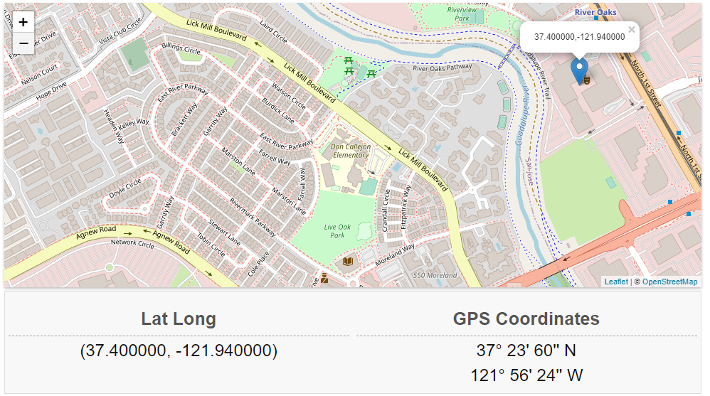

[figure not shown]

```python
#drop rows where start_station_name column has missing value
df_clean = df_clean[pd.notnull(df_clean['start_station_name'])]
```

```python
#control if there is missing value
df_clean.info()
```

```
<class 'pandas.core.frame.DataFrame'>
Int64Index: 174952 entries, 0 to 183411
Data columns (total 16 columns):
duration_sec               174952 non-null int64
start_time                 174952 non-null datetime64[ns]
end_time                   174952 non-null datetime64[ns]
start_station_id           174952 non-null float64
start_station_name         174952 non-null object
start_station_latitude     174952 non-null float64
start_station_longitude    174952 non-null float64
end_station_id             174952 non-null float64
end_station_name           174952 non-null object
end_station_latitude       174952 non-null float64
end_station_longitude      174952 non-null float64
bike_id                    174952 non-null int64
user_type                  174952 non-null category
member_birth_year          174952 non-null int64
member_gender              174952 non-null category
bike_share_for_all_trip    174952 non-null object
dtypes: category(2), datetime64[ns](2), float64(6), int64(3), object(3)
memory usage: 20.4+ MB
```

```python
#fix data types
df_clean['start_station_id'] = df_clean['start_station_id'].astype(int)
df_clean['end_station_id'] = df_clean['end_station_id'].astype(int)
```

```python
#I have decided to drops below columns where member birth date is less than 1945
df_clean[df_clean['member_birth_year']<1945]
```

|  | duration_sec | start_time | end_time | start_station_id | start_station_name | start_station_latitude | start_station_longitude | end_station_id | end_station_name | end_station_latitude | end_station_longitude | bike_id | user_type | member_birth_year | member_gender | bike_share_for_all_trip |
| --- | --- | --- | --- | --- | --- | --- | --- | --- | --- | --- | --- | --- | --- | --- | --- | --- |
| 1285 | 148 | 2019-02-28 19:29:17.627 | 2019-02-28 19:31:45.967 | 158 | Shattuck Ave at Telegraph Ave | 37.833279 | -122.263490 | 173 | Shattuck Ave at 55th St | 37.840364 | -122.264488 | 5391 | Subscriber | 1900 | Male | Yes |
| 2085 | 694 | 2019-02-28 18:21:05.187 | 2019-02-28 18:32:39.596 | 107 | 17th St at Dolores St | 37.763015 | -122.426497 | 89 | Division St at Potrero Ave | 37.769218 | -122.407646 | 385 | Subscriber | 1941 | Male | No |
| 5197 | 217 | 2019-02-28 13:51:46.238 | 2019-02-28 13:55:24.127 | 70 | Central Ave at Fell St | 37.773311 | -122.444293 | 71 | Broderick St at Oak St | 37.773063 | -122.439078 | 5801 | Subscriber | 1931 | Male | No |
| 5249 | 1396 | 2019-02-28 13:21:36.678 | 2019-02-28 13:44:53.057 | 22 | Howard St at Beale St | 37.789756 | -122.394643 | 74 | Laguna St at Hayes St | 37.776435 | -122.426244 | 623 | Subscriber | 1943 | Female | No |
| 5266 | 384 | 2019-02-28 13:35:05.428 | 2019-02-28 13:41:30.223 | 84 | Duboce Park | 37.769201 | -122.433812 | 71 | Broderick St at Oak St | 37.773063 | -122.439078 | 6608 | Subscriber | 1931 | Male | No |
| 5447 | 147 | 2019-02-28 13:08:56.935 | 2019-02-28 13:11:24.062 | 84 | Duboce Park | 37.769201 | -122.433812 | 72 | Page St at Scott St | 37.772406 | -122.435650 | 5018 | Subscriber | 1931 | Male | No |
| 10827 | 1315 | 2019-02-27 19:21:34.436 | 2019-02-27 19:43:30.008 | 343 | Bryant St at 2nd St | 37.783172 | -122.393572 | 375 | Grove St at Masonic Ave | 37.774836 | -122.446546 | 6249 | Subscriber | 1900 | Male | No |
| 13675 | 554 | 2019-02-27 15:09:41.550 | 2019-02-27 15:18:55.971 | 27 | Beale St at Harrison St | 37.788059 | -122.391865 | 30 | San Francisco Caltrain (Townsend St at 4th St) | 37.776598 | -122.395282 | 5855 | Subscriber | 1942 | Male | No |
| 16087 | 1131 | 2019-02-27 08:37:36.864 | 2019-02-27 08:56:28.022 | 375 | Grove St at Masonic Ave | 37.774836 | -122.446546 | 36 | Folsom St at 3rd St | 37.783830 | -122.398870 | 4968 | Subscriber | 1900 | Male | No |
| 17981 | 366 | 2019-02-26 19:53:38.528 | 2019-02-26 19:59:44.968 | 50 | 2nd St at Townsend St | 37.780526 | -122.390288 | 21 | Montgomery St BART Station (Market St at 2nd St) | 37.789625 | -122.400811 | 5226 | Subscriber | 1920 | Male | No |
| 18560 | 578 | 2019-02-26 18:17:31.290 | 2019-02-26 18:27:09.307 | 58 | Market St at 10th St | 37.776619 | -122.417385 | 89 | Division St at Potrero Ave | 37.769218 | -122.407646 | 183 | Subscriber | 1941 | Male | No |
| 18885 | 432 | 2019-02-26 17:48:59.016 | 2019-02-26 17:56:11.370 | 21 | Montgomery St BART Station (Market St at 2nd St) | 37.789625 | -122.400811 | 50 | 2nd St at Townsend St | 37.780526 | -122.390288 | 5319 | Subscriber | 1920 | Male | No |
| 19375 | 641 | 2019-02-26 17:03:19.855 | 2019-02-26 17:14:01.619 | 9 | Broadway at Battery St | 37.798572 | -122.400869 | 30 | San Francisco Caltrain (Townsend St at 4th St) | 37.776598 | -122.395282 | 6164 | Customer | 1900 | Male | No |
| 20743 | 380 | 2019-02-26 10:57:07.767 | 2019-02-26 11:03:28.196 | 26 | 1st St at Folsom St | 37.787290 | -122.394380 | 61 | Howard St at 8th St | 37.776513 | -122.411306 | 5387 | Subscriber | 1933 | Female | Yes |
| 21424 | 1424 | 2019-02-26 08:58:02.904 | 2019-02-26 09:21:47.749 | 375 | Grove St at Masonic Ave | 37.774836 | -122.446546 | 343 | Bryant St at 2nd St | 37.783172 | -122.393572 | 5344 | Subscriber | 1900 | Male | No |
| 21506 | 701 | 2019-02-26 09:06:11.239 | 2019-02-26 09:17:52.442 | 67 | San Francisco Caltrain Station 2 (Townsend St... | 37.776639 | -122.395526 | 9 | Broadway at Battery St | 37.798572 | -122.400869 | 5337 | Customer | 1900 | Male | No |
| 24042 | 194 | 2019-02-25 18:58:10.644 | 2019-02-25 19:01:25.308 | 158 | Shattuck Ave at Telegraph Ave | 37.833279 | -122.263490 | 173 | Shattuck Ave at 55th St | 37.840364 | -122.264488 | 6363 | Subscriber | 1900 | Male | Yes |
| 26133 | 410 | 2019-02-25 13:38:12.067 | 2019-02-25 13:45:02.207 | 173 | Shattuck Ave at 55th St | 37.840364 | -122.264488 | 176 | MacArthur BART Station | 37.828410 | -122.266315 | 3311 | Subscriber | 1900 | Male | Yes |
| 26344 | 534 | 2019-02-25 12:43:50.225 | 2019-02-25 12:52:45.128 | 26 | 1st St at Folsom St | 37.787290 | -122.394380 | 61 | Howard St at 8th St | 37.776513 | -122.411306 | 5948 | Subscriber | 1933 | Female | Yes |
| 26488 | 334 | 2019-02-25 12:13:25.330 | 2019-02-25 12:18:59.434 | 71 | Broderick St at Oak St | 37.773063 | -122.439078 | 84 | Duboce Park | 37.769201 | -122.433812 | 3361 | Subscriber | 1931 | Male | No |
| 26535 | 119 | 2019-02-25 12:08:38.311 | 2019-02-25 12:10:37.660 | 71 | Broderick St at Oak St | 37.773063 | -122.439078 | 53 | Grove St at Divisadero | 37.775946 | -122.437777 | 6475 | Subscriber | 1931 | Male | No |
| 26568 | 135 | 2019-02-25 12:02:18.360 | 2019-02-25 12:04:34.272 | 71 | Broderick St at Oak St | 37.773063 | -122.439078 | 53 | Grove St at Divisadero | 37.775946 | -122.437777 | 6257 | Subscriber | 1931 | Male | No |
| 26604 | 294 | 2019-02-25 11:52:12.537 | 2019-02-25 11:57:06.985 | 85 | Church St at Duboce Ave | 37.770083 | -122.429156 | 53 | Grove St at Divisadero | 37.775946 | -122.437777 | 5814 | Subscriber | 1931 | Male | No |
| 26641 | 78 | 2019-02-25 11:50:14.777 | 2019-02-25 11:51:33.555 | 85 | Church St at Duboce Ave | 37.770083 | -122.429156 | 85 | Church St at Duboce Ave | 37.770083 | -122.429156 | 4361 | Subscriber | 1931 | Male | No |
| 26685 | 110 | 2019-02-25 11:40:27.348 | 2019-02-25 11:42:17.782 | 85 | Church St at Duboce Ave | 37.770083 | -122.429156 | 73 | Pierce St at Haight St | 37.771793 | -122.433708 | 6208 | Subscriber | 1931 | Male | No |
| 26718 | 138 | 2019-02-25 11:33:27.172 | 2019-02-25 11:35:45.176 | 71 | Broderick St at Oak St | 37.773063 | -122.439078 | 73 | Pierce St at Haight St | 37.771793 | -122.433708 | 6110 | Subscriber | 1931 | Male | No |
| 26757 | 81 | 2019-02-25 11:25:52.753 | 2019-02-25 11:27:14.706 | 375 | Grove St at Masonic Ave | 37.774836 | -122.446546 | 70 | Central Ave at Fell St | 37.773311 | -122.444293 | 579 | Subscriber | 1931 | Male | No |
| 26775 | 130 | 2019-02-25 11:21:03.469 | 2019-02-25 11:23:13.569 | 71 | Broderick St at Oak St | 37.773063 | -122.439078 | 70 | Central Ave at Fell St | 37.773311 | -122.444293 | 5354 | Subscriber | 1931 | Male | No |
| 26807 | 116 | 2019-02-25 11:14:28.437 | 2019-02-25 11:16:25.262 | 375 | Grove St at Masonic Ave | 37.774836 | -122.446546 | 70 | Central Ave at Fell St | 37.773311 | -122.444293 | 74 | Subscriber | 1931 | Male | No |
| 26828 | 139 | 2019-02-25 11:08:41.602 | 2019-02-25 11:11:01.559 | 71 | Broderick St at Oak St | 37.773063 | -122.439078 | 70 | Central Ave at Fell St | 37.773311 | -122.444293 | 1428 | Subscriber | 1931 | Male | No |
| ... | ... | ... | ... | ... | ... | ... | ... | ... | ... | ... | ... | ... | ... | ... | ... | ... |
| 153746 | 331 | 2019-02-06 11:48:52.091 | 2019-02-06 11:54:23.653 | 127 | Valencia St at 21st St | 37.756708 | -122.421025 | 110 | 17th & Folsom Street Park (17th St at Folsom St) | 37.763708 | -122.415204 | 5112 | Subscriber | 1938 | Male | No |
| 157035 | 335 | 2019-02-06 06:36:44.481 | 2019-02-06 06:42:20.308 | 84 | Duboce Park | 37.769201 | -122.433812 | 118 | Eureka Valley Recreation Center | 37.759177 | -122.436943 | 3303 | Subscriber | 1931 | Male | No |
| 158882 | 645 | 2019-02-05 18:30:58.841 | 2019-02-05 18:41:43.860 | 58 | Market St at 10th St | 37.776619 | -122.417385 | 89 | Division St at Potrero Ave | 37.769218 | -122.407646 | 2741 | Subscriber | 1941 | Male | No |
| 159405 | 584 | 2019-02-05 17:59:16.244 | 2019-02-05 18:09:00.940 | 26 | 1st St at Folsom St | 37.787290 | -122.394380 | 5 | Powell St BART Station (Market St at 5th St) | 37.783899 | -122.408445 | 5098 | Subscriber | 1933 | Female | Yes |
| 160965 | 512 | 2019-02-05 16:16:28.102 | 2019-02-05 16:25:00.469 | 27 | Beale St at Harrison St | 37.788059 | -122.391865 | 30 | San Francisco Caltrain (Townsend St at 4th St) | 37.776598 | -122.395282 | 5573 | Subscriber | 1942 | Male | No |
| 161129 | 393 | 2019-02-05 15:57:21.589 | 2019-02-05 16:03:55.187 | 30 | San Francisco Caltrain (Townsend St at 4th St) | 37.776598 | -122.395282 | 27 | Beale St at Harrison St | 37.788059 | -122.391865 | 5573 | Subscriber | 1942 | Male | No |
| 161505 | 355 | 2019-02-05 14:43:59.227 | 2019-02-05 14:49:54.267 | 25 | Howard St at 2nd St | 37.787522 | -122.397405 | 30 | San Francisco Caltrain (Townsend St at 4th St) | 37.776598 | -122.395282 | 4928 | Subscriber | 1902 | Female | No |
| 162051 | 176 | 2019-02-05 13:00:00.604 | 2019-02-05 13:02:57.549 | 173 | Shattuck Ave at 55th St | 37.840364 | -122.264488 | 174 | Shattuck Ave at 51st St | 37.836801 | -122.264004 | 2442 | Subscriber | 1900 | Male | Yes |
| 163112 | 1640 | 2019-02-05 09:18:18.397 | 2019-02-05 09:45:39.016 | 377 | Fell St at Stanyan St | 37.771917 | -122.453704 | 36 | Folsom St at 3rd St | 37.783830 | -122.398870 | 2715 | Subscriber | 1900 | Male | No |
| 165505 | 255 | 2019-02-05 06:52:54.194 | 2019-02-05 06:57:10.083 | 84 | Duboce Park | 37.769201 | -122.433812 | 118 | Eureka Valley Recreation Center | 37.759177 | -122.436943 | 5381 | Subscriber | 1931 | Male | No |
| 165811 | 291 | 2019-02-04 22:09:05.110 | 2019-02-04 22:13:57.024 | 88 | 11th St at Bryant St | 37.770030 | -122.411726 | 79 | 7th St at Brannan St | 37.773492 | -122.403673 | 5408 | Subscriber | 1943 | Male | Yes |
| 167178 | 526 | 2019-02-04 17:36:54.155 | 2019-02-04 17:45:41.140 | 25 | Howard St at 2nd St | 37.787522 | -122.397405 | 30 | San Francisco Caltrain (Townsend St at 4th St) | 37.776598 | -122.395282 | 184 | Subscriber | 1902 | Female | No |
| 167979 | 269 | 2019-02-04 16:33:10.017 | 2019-02-04 16:37:39.805 | 211 | Broadway at 40th St | 37.827757 | -122.256716 | 176 | MacArthur BART Station | 37.828410 | -122.266315 | 5074 | Subscriber | 1942 | Male | No |
| 169191 | 508 | 2019-02-04 11:47:38.038 | 2019-02-04 11:56:06.600 | 27 | Beale St at Harrison St | 37.788059 | -122.391865 | 30 | San Francisco Caltrain (Townsend St at 4th St) | 37.776598 | -122.395282 | 3241 | Subscriber | 1942 | Male | No |
| 171086 | 1086 | 2019-02-04 06:30:33.383 | 2019-02-04 06:48:39.869 | 375 | Grove St at Masonic Ave | 37.774836 | -122.446546 | 36 | Folsom St at 3rd St | 37.783830 | -122.398870 | 4435 | Subscriber | 1900 | Male | No |
| 171757 | 94 | 2019-02-03 19:12:06.607 | 2019-02-03 19:13:40.671 | 173 | Shattuck Ave at 55th St | 37.840364 | -122.264488 | 174 | Shattuck Ave at 51st St | 37.836801 | -122.264004 | 4539 | Subscriber | 1900 | Male | Yes |
| 171996 | 1368 | 2019-02-03 17:33:54.607 | 2019-02-03 17:56:42.949 | 37 | 2nd St at Folsom St | 37.785000 | -122.395936 | 375 | Grove St at Masonic Ave | 37.774836 | -122.446546 | 4988 | Subscriber | 1900 | Male | No |
| 173711 | 993 | 2019-02-03 09:45:30.464 | 2019-02-03 10:02:04.169 | 375 | Grove St at Masonic Ave | 37.774836 | -122.446546 | 36 | Folsom St at 3rd St | 37.783830 | -122.398870 | 5445 | Subscriber | 1900 | Male | No |
| 175394 | 1310 | 2019-02-02 14:17:10.232 | 2019-02-02 14:39:00.412 | 85 | Church St at Duboce Ave | 37.770083 | -122.429156 | 89 | Division St at Potrero Ave | 37.769218 | -122.407646 | 5125 | Customer | 1939 | Male | No |
| 175698 | 312 | 2019-02-02 13:43:50.589 | 2019-02-02 13:49:03.380 | 30 | San Francisco Caltrain (Townsend St at 4th St) | 37.776598 | -122.395282 | 27 | Beale St at Harrison St | 37.788059 | -122.391865 | 5359 | Subscriber | 1942 | Male | No |
| 175858 | 366 | 2019-02-02 13:15:59.583 | 2019-02-02 13:22:06.537 | 28 | The Embarcadero at Bryant St | 37.787168 | -122.388098 | 30 | San Francisco Caltrain (Townsend St at 4th St) | 37.776598 | -122.395282 | 5359 | Subscriber | 1942 | Male | No |
| 176220 | 310 | 2019-02-02 12:11:19.415 | 2019-02-02 12:16:30.203 | 284 | Yerba Buena Center for the Arts (Howard St at ... | 37.784872 | -122.400876 | 27 | Beale St at Harrison St | 37.788059 | -122.391865 | 5549 | Subscriber | 1942 | Male | No |
| 177708 | 1527 | 2019-02-01 19:09:28.387 | 2019-02-01 19:34:55.963 | 343 | Bryant St at 2nd St | 37.783172 | -122.393572 | 375 | Grove St at Masonic Ave | 37.774836 | -122.446546 | 5286 | Subscriber | 1900 | Male | No |
| 177885 | 517 | 2019-02-01 18:38:40.471 | 2019-02-01 18:47:18.392 | 25 | Howard St at 2nd St | 37.787522 | -122.397405 | 30 | San Francisco Caltrain (Townsend St at 4th St) | 37.776598 | -122.395282 | 2175 | Subscriber | 1902 | Female | No |
| 177955 | 377 | 2019-02-01 18:23:33.411 | 2019-02-01 18:29:50.795 | 26 | 1st St at Folsom St | 37.787290 | -122.394380 | 321 | 5th St at Folsom | 37.780146 | -122.403071 | 5444 | Subscriber | 1933 | Female | Yes |
| 179280 | 355 | 2019-02-01 14:32:42.247 | 2019-02-01 14:38:37.896 | 134 | Valencia St at 24th St | 37.752428 | -122.420628 | 131 | 22nd St at Dolores St | 37.755000 | -122.425728 | 1815 | Subscriber | 1938 | Male | No |
| 180728 | 362 | 2019-02-01 10:13:44.871 | 2019-02-01 10:19:47.762 | 30 | San Francisco Caltrain (Townsend St at 4th St) | 37.776598 | -122.395282 | 27 | Beale St at Harrison St | 37.788059 | -122.391865 | 4877 | Subscriber | 1942 | Male | No |
| 181019 | 494 | 2019-02-01 09:38:06.311 | 2019-02-01 09:46:21.165 | 27 | Beale St at Harrison St | 37.788059 | -122.391865 | 30 | San Francisco Caltrain (Townsend St at 4th St) | 37.776598 | -122.395282 | 5474 | Subscriber | 1942 | Male | No |
| 182830 | 428 | 2019-02-01 07:45:05.934 | 2019-02-01 07:52:14.922 | 284 | Yerba Buena Center for the Arts (Howard St at ... | 37.784872 | -122.400876 | 67 | San Francisco Caltrain Station 2 (Townsend St... | 37.776639 | -122.395526 | 5031 | Subscriber | 1901 | Male | No |
| 183388 | 490 | 2019-02-01 00:39:53.112 | 2019-02-01 00:48:03.338 | 61 | Howard St at 8th St | 37.776513 | -122.411306 | 81 | Berry St at 4th St | 37.775880 | -122.393170 | 5411 | Subscriber | 1927 | Male | No |

265 rows × 16 columns

```python
df_clean.drop(df_clean.loc[df_clean['member_birth_year']<=1945].index, inplace=True)
```

```python
#control if there birth year less than 1945
df_clean.query('member_birth_year <1945')
```

|  | duration_sec | start_time | end_time | start_station_id | start_station_name | start_station_latitude | start_station_longitude | end_station_id | end_station_name | end_station_latitude | end_station_longitude | bike_id | user_type | member_birth_year | member_gender | bike_share_for_all_trip |
| --- | --- | --- | --- | --- | --- | --- | --- | --- | --- | --- | --- | --- | --- | --- | --- | --- |

```python
#create date, day,time column
df_clean['trip_month'] = df_clean.start_time.dt.strftime('%b')
df_clean['trip_day'] = df_clean.start_time.dt.strftime('%a')
df_clean['trip_hour'] = df_clean.start_time.dt.strftime('%H')
```

```python
df_clean.head()
```

|  | duration_sec | start_time | end_time | start_station_id | start_station_name | start_station_latitude | start_station_longitude | end_station_id | end_station_name | end_station_latitude | end_station_longitude | bike_id | user_type | member_birth_year | member_gender | bike_share_for_all_trip | trip_month | trip_day | trip_hour |
| --- | --- | --- | --- | --- | --- | --- | --- | --- | --- | --- | --- | --- | --- | --- | --- | --- | --- | --- | --- |
| 0 | 52185 | 2019-02-28 17:32:10.145 | 2019-03-01 08:01:55.975 | 21 | Montgomery St BART Station (Market St at 2nd St) | 37.789625 | -122.400811 | 13 | Commercial St at Montgomery St | 37.794231 | -122.402923 | 4902 | Customer | 1984 | Male | No | Feb | Thu | 17 |
| 2 | 61854 | 2019-02-28 12:13:13.218 | 2019-03-01 05:24:08.146 | 86 | Market St at Dolores St | 37.769305 | -122.426826 | 3 | Powell St BART Station (Market St at 4th St) | 37.786375 | -122.404904 | 5905 | Customer | 1972 | Male | No | Feb | Thu | 12 |
| 3 | 36490 | 2019-02-28 17:54:26.010 | 2019-03-01 04:02:36.842 | 375 | Grove St at Masonic Ave | 37.774836 | -122.446546 | 70 | Central Ave at Fell St | 37.773311 | -122.444293 | 6638 | Subscriber | 1989 | Other | No | Feb | Thu | 17 |
| 4 | 1585 | 2019-02-28 23:54:18.549 | 2019-03-01 00:20:44.074 | 7 | Frank H Ogawa Plaza | 37.804562 | -122.271738 | 222 | 10th Ave at E 15th St | 37.792714 | -122.248780 | 4898 | Subscriber | 1974 | Male | Yes | Feb | Thu | 23 |
| 5 | 1793 | 2019-02-28 23:49:58.632 | 2019-03-01 00:19:51.760 | 93 | 4th St at Mission Bay Blvd S | 37.770407 | -122.391198 | 323 | Broadway at Kearny | 37.798014 | -122.405950 | 5200 | Subscriber | 1959 | Male | No | Feb | Thu | 23 |

```python
#fix trip hour data type
df_clean['trip_hour']= df_clean['trip_hour'].astype(int)
```

```python
# create new column as period
df_clean['period'] = (df_clean['trip_hour']% 24 + 4) // 4
df_clean['period'].replace({1: 'Late Night',
                      2: 'Early Morning',
                      3: 'Morning',
                      4: 'Noon',
                      5: 'Evening',
                      6: 'Night'}, inplace=True)
```

```python
#create age column
df_clean['age']=2020-df_clean['member_birth_year']
```

## DATA ANALYSIS

### 1. UNIVARIATE EXPLORATION

```python
base_color = sb.color_palette()[0]
```

```python
freq = df_clean['member_gender'].value_counts()

# Get the indexes of the Series
gen_order = freq.index
```

## Participants Gender Distribution

3619 participants did not state their gender yet graphic shows clearly that male gender participated more than females. %74.6 of participants are male.

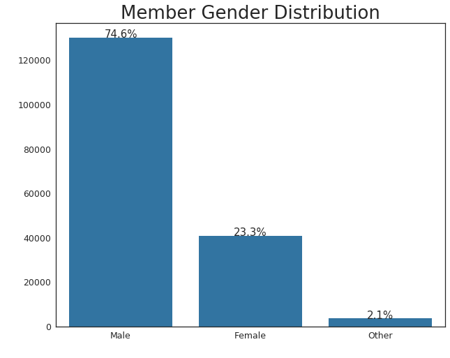

```python
sb.set(rc={"font.style":"normal",
            "text.color":"black",
            "xtick.color":"black",
            "ytick.color":"black",
            "axes.labelcolor":"black",
            "axes.grid":False,
            'axes.labelsize':30,
            'figure.figsize':(10.0, 8.0),
            'xtick.labelsize':25,})
sb.set(style="white",font_scale=1.25)

ax=sb.countplot(x ='member_gender', data = df_clean, color=base_color,order=gen_order)
plt.title('Member Gender Distribution', fontsize=26)
plt.xlabel(" ")
plt.ylabel(" ")

bars = ax.patches

total=bars[0].get_height()+bars[1].get_height()+bars[2].get_height()

for p in ax.patches:
    percentage = '{:.1f}%'.format(100 * p.get_height()/total)
    x = p.get_x() + p.get_width()
    y = p.get_height()+0.6
    ax.annotate(percentage, (x-0.4, y),ha='center')

plt.show()
```

## User Types Distribution

%90.5 participants defined as subscriber, %9.5 participants are costumer.

```python
#Distribution of type of users
data = df_clean['user_type'].value_counts()/df_clean['user_type'].value_counts().sum()
```

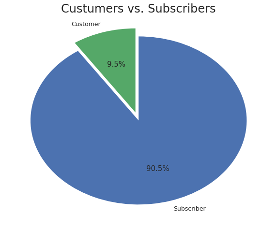

```python
explode = (0, 0.1)
plt.title('Custumers vs. Subscribers',fontsize=24)
plt.pie(data, labels = data.index, startangle = 90, counterclock = False,explode=explode,autopct='%1.1f%%');
```

## Bike Share Distribution

%90.1 participants said "No". Most of participants did not share their bikes.

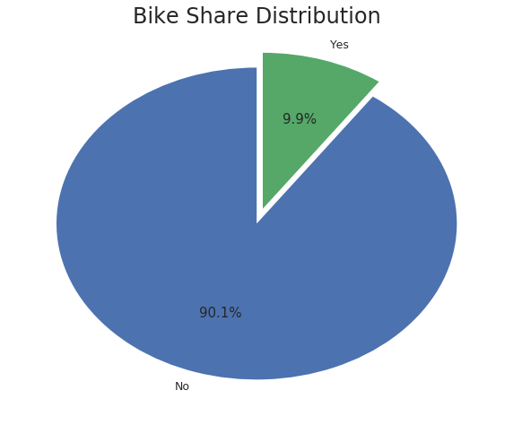

```python
#Distribution of type of users
data = df_clean['bike_share_for_all_trip'].value_counts()/df_clean['bike_share_for_all_trip'].value_counts().sum()
explode = (0, 0.1)
plt.pie(data, labels = data.index, autopct='%1.1f%%' , startangle = 90, explode=explode)
plt.title('Bike Share Distribution', fontsize=24);
plt.figure(figsize=(1,1))
```

```python
df_clean['member_birth_year'].describe()
```

```
count    174582.000000
mean       1984.916733
std           9.794782
min        1946.000000
25%        1980.000000
50%        1987.000000
75%        1992.000000
max        2001.000000
Name: member_birth_year, dtype: float64
```

## Member Birth Year Distribution

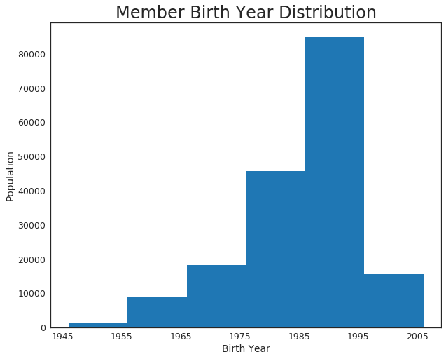

```python
bins = np.arange(1946, df_clean['member_birth_year'].max()+10, 10)

plt.hist(data = df_clean, x = 'member_birth_year', bins = bins, color=base_color)
plt.xlabel('Birth Year')
plt.ylabel('Population')
plt.title('Member Birth Year Distribution', fontsize=24)

plt.xticks(np.arange(1945, 2010, 10))

plt.show()
```

```python
df_clean['duration_sec'].describe()
```

```
count    174582.000000
mean        704.297018
std        1643.699032
min          61.000000
25%         323.000000
50%         511.000000
75%         789.000000
max       84548.000000
Name: duration_sec, dtype: float64
```

## DURATION OF TRIP DISTRIBUTION

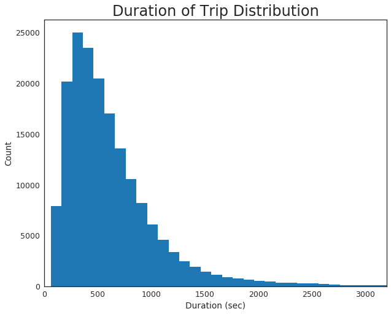

```python
bins = np.arange(61, df_clean['duration_sec'].max()+10, 100)

plt.hist(data = df_clean, x = 'duration_sec', bins = bins, color=base_color)
plt.xlim((0,3200));
plt.xlabel('Duration (sec)')
plt.ylabel('Count')
plt.title('Duration of Trip Distribution', fontsize=24)
plt.show()
```